# Project: Identify Customer Segments

In this project, you will apply unsupervised learning techniques to identify segments of the population that form the core customer base for a mail-order sales company in Germany. These segments can then be used to direct marketing campaigns towards audiences that will have the highest expected rate of returns. The data that you will use has been provided by our partners at Bertelsmann Arvato Analytics, and represents a real-life data science task.

This notebook will help you complete this task by providing a framework within which you will perform your analysis steps. In each step of the project, you will see some text describing the subtask that you will perform, followed by one or more code cells for you to complete your work. **Feel free to add additional code and markdown cells as you go along so that you can explore everything in precise chunks.** The code cells provided in the base template will outline only the major tasks, and will usually not be enough to cover all of the minor tasks that comprise it.

It should be noted that while there will be precise guidelines on how you should handle certain tasks in the project, there will also be places where an exact specification is not provided. **There will be times in the project where you will need to make and justify your own decisions on how to treat the data.** These are places where there may not be only one way to handle the data. In real-life tasks, there may be many valid ways to approach an analysis task. One of the most important things you can do is clearly document your approach so that other scientists can understand the decisions you've made.

At the end of most sections, there will be a Markdown cell labeled **Discussion**. In these cells, you will report your findings for the completed section, as well as document the decisions that you made in your approach to each subtask. **Your project will be evaluated not just on the code used to complete the tasks outlined, but also your communication about your observations and conclusions at each stage.**

```python
# import libraries here; add more as necessary
import time
import numpy as np
import pandas as pd
import matplotlib.pyplot as plt
import seaborn as sns


# magic word for producing visualizations in notebook
%matplotlib inline

#disable warning
pd.options.mode.chained_assignment = None
'''
Import note: The classroom currently uses sklearn version 0.19.
If you need to use an imputer, it is available in sklearn.preprocessing.Imputer,
instead of sklearn.impute as in newer versions of sklearn.
'''
```

```
'\nImport note: The classroom currently uses sklearn version 0.19.\nIf you need to use an imputer, it is available in sklearn.preprocessing.Imputer,\ninstead of sklearn.impute as in newer versions of sklearn.\n'
```

```python
from sklearn.preprocessing import StandardScaler
from sklearn.decomposition import PCA
from sklearn.cluster import KMeans
```

```python
from sklearn.experimental import enable_iterative_imputer
from sklearn.impute import IterativeImputer
```

### Step 0: Load the Data

Each row of the demographics files represents a single person, but also includes information outside of individuals, including information about their household, building, and neighborhood. You will use this information to cluster the general population into groups with similar demographic properties. Then, you will see how the people in the customers dataset fit into those created clusters. The hope here is that certain clusters are over-represented in the customers data, as compared to the general population; those over-represented clusters will be assumed to be part of the core userbase. This information can then be used for further applications, such as targeting for a marketing campaign.

To start off with, load in the demographics data for the general population into a pandas DataFrame, and do the same for the feature attributes summary. Note for all of the `.csv` data files in this project: they're semicolon (`;`) delimited, so you'll need an additional argument in your [`read_csv()`](https://pandas.pydata.org/pandas-docs/stable/generated/pandas.read_csv.html) call to read in the data properly. Also, considering the size of the main dataset, it may take some time for it to load completely.

Once the dataset is loaded, it's recommended that you take a little bit of time just browsing the general structure of the dataset and feature summary file. You'll be getting deep into the innards of the cleaning in the first major step of the project, so gaining some general familiarity can help you get your bearings.

```python
# Load in the general demographics data.
azdias = pd.read_csv('./Udacity_AZDIAS_Subset.csv', delimiter=';')

# Load in the feature summary file.
feat_info = pd.read_csv('./AZDIAS_Feature_Summary.csv', delimiter=';')
```

```python
# demographics data info
azdias.info()
```

```
<class 'pandas.core.frame.DataFrame'>
RangeIndex: 891221 entries, 0 to 891220
Data columns (total 85 columns):
 #   Column                 Non-Null Count   Dtype
---  ------                 --------------   -----
 0   AGER_TYP               891221 non-null  int64
 1   ALTERSKATEGORIE_GROB   891221 non-null  int64
 2   ANREDE_KZ              891221 non-null  int64
 3   CJT_GESAMTTYP          886367 non-null  float64
 4   FINANZ_MINIMALIST      891221 non-null  int64
 5   FINANZ_SPARER          891221 non-null  int64
 6   FINANZ_VORSORGER       891221 non-null  int64
 7   FINANZ_ANLEGER         891221 non-null  int64
 8   FINANZ_UNAUFFAELLIGER  891221 non-null  int64
 9   FINANZ_HAUSBAUER       891221 non-null  int64
```

[output cut: 77 more lines]

```python
# feature summary data info
feat_info.info()
```

```
<class 'pandas.core.frame.DataFrame'>
RangeIndex: 85 entries, 0 to 84
Data columns (total 4 columns):
 #   Column              Non-Null Count  Dtype
---  ------              --------------  -----
 0   attribute           85 non-null     object
 1   information_level   85 non-null     object
 2   type                85 non-null     object
 3   missing_or_unknown  85 non-null     object
dtypes: object(4)
memory usage: 2.8+ KB
```

Next we need to :

- Print first 5 records 'head()'
- Print Total number of recoreds and columns 'shape'
- Print descriptive statistics 'describe()'

for 'azdias' and 'feat_info' respectively

#### Step 0.1: Explore azidas dataset

```python
# Print the first 5 records
azdias.head(n = 5)
```

|  | AGER_TYP | ALTERSKATEGORIE_GROB | ANREDE_KZ | CJT_GESAMTTYP | FINANZ_MINIMALIST | FINANZ_SPARER | FINANZ_VORSORGER | FINANZ_ANLEGER | FINANZ_UNAUFFAELLIGER | FINANZ_HAUSBAUER | ... | PLZ8_ANTG1 | PLZ8_ANTG2 | PLZ8_ANTG3 | PLZ8_ANTG4 | PLZ8_BAUMAX | PLZ8_HHZ | PLZ8_GBZ | ARBEIT | ORTSGR_KLS9 | RELAT_AB |
| --- | --- | --- | --- | --- | --- | --- | --- | --- | --- | --- | --- | --- | --- | --- | --- | --- | --- | --- | --- | --- | --- |
| 0 | -1 | 2 | 1 | 2.0 | 3 | 4 | 3 | 5 | 5 | 3 | ... | NaN | NaN | NaN | NaN | NaN | NaN | NaN | NaN | NaN | NaN |
| 1 | -1 | 1 | 2 | 5.0 | 1 | 5 | 2 | 5 | 4 | 5 | ... | 2.0 | 3.0 | 2.0 | 1.0 | 1.0 | 5.0 | 4.0 | 3.0 | 5.0 | 4.0 |
| 2 | -1 | 3 | 2 | 3.0 | 1 | 4 | 1 | 2 | 3 | 5 | ... | 3.0 | 3.0 | 1.0 | 0.0 | 1.0 | 4.0 | 4.0 | 3.0 | 5.0 | 2.0 |
| 3 | 2 | 4 | 2 | 2.0 | 4 | 2 | 5 | 2 | 1 | 2 | ... | 2.0 | 2.0 | 2.0 | 0.0 | 1.0 | 3.0 | 4.0 | 2.0 | 3.0 | 3.0 |
| 4 | -1 | 3 | 1 | 5.0 | 4 | 3 | 4 | 1 | 3 | 2 | ... | 2.0 | 4.0 | 2.0 | 1.0 | 2.0 | 3.0 | 3.0 | 4.0 | 6.0 | 5.0 |

5 rows × 85 columns

```python
# Check the structure of the data after it's loaded (e.g. print the number of
# rows and columns).
d_s = azdias.shape
print("Shape of data: {}".format(d_s))
print("Total number of records: {}".format(d_s[0]))
print("Total number of columns : {}".format(d_s[1]))
```

```
Shape of data: (891221, 85)
Total number of records: 891221
Total number of columns : 85
```

```python
# data exploration
azdias.describe()
```

|  | AGER_TYP | ALTERSKATEGORIE_GROB | ANREDE_KZ | CJT_GESAMTTYP | FINANZ_MINIMALIST | FINANZ_SPARER | FINANZ_VORSORGER | FINANZ_ANLEGER | FINANZ_UNAUFFAELLIGER | FINANZ_HAUSBAUER | ... | PLZ8_ANTG1 | PLZ8_ANTG2 | PLZ8_ANTG3 | PLZ8_ANTG4 | PLZ8_BAUMAX | PLZ8_HHZ | PLZ8_GBZ | ARBEIT | ORTSGR_KLS9 | RELAT_AB |
| --- | --- | --- | --- | --- | --- | --- | --- | --- | --- | --- | --- | --- | --- | --- | --- | --- | --- | --- | --- | --- | --- |
| count | 891221.000000 | 891221.000000 | 891221.000000 | 886367.000000 | 891221.000000 | 891221.000000 | 891221.000000 | 891221.000000 | 891221.000000 | 891221.000000 | ... | 774706.000000 | 774706.000000 | 774706.000000 | 774706.000000 | 774706.000000 | 774706.000000 | 774706.000000 | 794005.000000 | 794005.000000 | 794005.00000 |
| mean | -0.358435 | 2.777398 | 1.522098 | 3.632838 | 3.074528 | 2.821039 | 3.401106 | 3.033328 | 2.874167 | 3.075121 | ... | 2.253330 | 2.801858 | 1.595426 | 0.699166 | 1.943913 | 3.612821 | 3.381087 | 3.167854 | 5.293002 | 3.07222 |
| std | 1.198724 | 1.068775 | 0.499512 | 1.595021 | 1.321055 | 1.464749 | 1.322134 | 1.529603 | 1.486731 | 1.353248 | ... | 0.972008 | 0.920309 | 0.986736 | 0.727137 | 1.459654 | 0.973967 | 1.111598 | 1.002376 | 2.303739 | 1.36298 |
| min | -1.000000 | 1.000000 | 1.000000 | 1.000000 | 1.000000 | 1.000000 | 1.000000 | 1.000000 | 1.000000 | 1.000000 | ... | 0.000000 | 0.000000 | 0.000000 | 0.000000 | 1.000000 | 1.000000 | 1.000000 | 1.000000 | 0.000000 | 1.00000 |
| 25% | -1.000000 | 2.000000 | 1.000000 | 2.000000 | 2.000000 | 1.000000 | 3.000000 | 2.000000 | 2.000000 | 2.000000 | ... | 1.000000 | 2.000000 | 1.000000 | 0.000000 | 1.000000 | 3.000000 | 3.000000 | 3.000000 | 4.000000 | 2.00000 |
| 50% | -1.000000 | 3.000000 | 2.000000 | 4.000000 | 3.000000 | 3.000000 | 3.000000 | 3.000000 | 3.000000 | 3.000000 | ... | 2.000000 | 3.000000 | 2.000000 | 1.000000 | 1.000000 | 4.000000 | 3.000000 | 3.000000 | 5.000000 | 3.00000 |
| 75% | -1.000000 | 4.000000 | 2.000000 | 5.000000 | 4.000000 | 4.000000 | 5.000000 | 5.000000 | 4.000000 | 4.000000 | ... | 3.000000 | 3.000000 | 2.000000 | 1.000000 | 3.000000 | 4.000000 | 4.000000 | 4.000000 | 7.000000 | 4.00000 |
| max | 3.000000 | 9.000000 | 2.000000 | 6.000000 | 5.000000 | 5.000000 | 5.000000 | 5.000000 | 5.000000 | 5.000000 | ... | 4.000000 | 4.000000 | 3.000000 | 2.000000 | 5.000000 | 5.000000 | 5.000000 | 9.000000 | 9.000000 | 9.00000 |

8 rows × 81 columns

#### Step 0.2: Explore feat_info

```python
# Print the first 5 records
feat_info.head(n = 5)
```

|  | attribute | information_level | type | missing_or_unknown |
| --- | --- | --- | --- | --- |
| 0 | AGER_TYP | person | categorical | [-1,0] |
| 1 | ALTERSKATEGORIE_GROB | person | ordinal | [-1,0,9] |
| 2 | ANREDE_KZ | person | categorical | [-1,0] |
| 3 | CJT_GESAMTTYP | person | categorical | [0] |
| 4 | FINANZ_MINIMALIST | person | ordinal | [-1] |

```python
# Check the structure of the data after it's loaded (e.g. print the number of
# rows and columns).
d_s = feat_info.shape
print("Shape of data: {}".format(d_s))
print("Total number of records: {}".format(d_s[0]))
print("Total number of columns : {}".format(d_s[1]))
```

```
Shape of data: (85, 4)
Total number of records: 85
Total number of columns : 4
```

```python
# data exploration
feat_info.describe()
```

|  | attribute | information_level | type | missing_or_unknown |
| --- | --- | --- | --- | --- |
| count | 85 | 85 | 85 | 85 |
| unique | 85 | 9 | 5 | 9 |
| top | AGER_TYP | person | ordinal | [-1] |
| freq | 1 | 43 | 49 | 26 |

> **Tip**: Add additional cells to keep everything in reasonably-sized chunks! Keyboard shortcut `esc --> a` (press escape to enter command mode, then press the 'A' key) adds a new cell before the active cell, and `esc --> b` adds a new cell after the active cell. If you need to convert an active cell to a markdown cell, use `esc --> m` and to convert to a code cell, use `esc --> y`.

## Step 1: Preprocessing

### Step 1.1: Assess Missing Data

The feature summary file contains a summary of properties for each demographics data column. You will use this file to help you make cleaning decisions during this stage of the project. First of all, you should assess the demographics data in terms of missing data. Pay attention to the following points as you perform your analysis, and take notes on what you observe. Make sure that you fill in the **Discussion** cell with your findings and decisions at the end of each step that has one!

#### Step 1.1.1: Convert Missing Value Codes to NaNs

The fourth column of the feature attributes summary (loaded in above as `feat_info`) documents the codes from the data dictionary that indicate missing or unknown data. While the file encodes this as a list (e.g. `[-1,0]`), this will get read in as a string object. You'll need to do a little bit of parsing to make use of it to identify and clean the data. Convert data that matches a 'missing' or 'unknown' value code into a numpy NaN value. You might want to see how much data takes on a 'missing' or 'unknown' code, and how much data is naturally missing, as a point of interest.

**As one more reminder, you are encouraged to add additional cells to break up your analysis into manageable chunks.**

```python
def full_print(data):
    pd.set_option('display.max_rows', None)
    print (data)
    pd.reset_option('display.max_rows')
```

```python
def format_str_to_array(df: pd.DataFrame, col_num: int):
    """
    Iterate over df indexing col_num and convert class 'str' to <class 'list'> e.g. '[1,2,3]' to [1,2,3]
    :param df: dataframe object
    :param col_num: column number in dataframe want to parse
    :return: df dataframe with parsed target column
    """
    for index, cols in df.iterrows():
        df.iloc[index, col_num] = df.iloc[index, col_num].strip('[]')
        if ( len (df.iloc[index, col_num]) == 0 ): # empty string
            df.iloc[index, col_num] = df.iloc[index, col_num].split() # '' to list []
        else:
            df.iloc[index, col_num] = df.iloc[index, col_num].split(',')
    return df
```

```python
# convert 4th column from string to array
format_str_to_array(feat_info, 3)
```

|  | attribute | information_level | type | missing_or_unknown |
| --- | --- | --- | --- | --- |
| 0 | AGER_TYP | person | categorical | [-1, 0] |
| 1 | ALTERSKATEGORIE_GROB | person | ordinal | [-1, 0, 9] |
| 2 | ANREDE_KZ | person | categorical | [-1, 0] |
| 3 | CJT_GESAMTTYP | person | categorical | [0] |
| 4 | FINANZ_MINIMALIST | person | ordinal | [-1] |
| ... | ... | ... | ... | ... |
| 80 | PLZ8_HHZ | macrocell_plz8 | ordinal | [-1] |
| 81 | PLZ8_GBZ | macrocell_plz8 | ordinal | [-1] |
| 82 | ARBEIT | community | ordinal | [-1, 9] |
| 83 | ORTSGR_KLS9 | community | ordinal | [-1, 0] |
| 84 | RELAT_AB | community | ordinal | [-1, 9] |

85 rows × 4 columns

```python
# Identify missing or unknown data values and convert them to NaNs.
def find_mis_vals_convert_to_nans(df: pd.DataFrame):
    start = time.time()
    for index, row in feat_info.iterrows():
        col_name = row.attribute
        mis_vals = feat_info.iloc[index, 3]
        # print ("column name {} and corrospinding missing values are {}".format(col_name, mis_vals))

        # determine the column(feature) type for comparison
        col_type = df[col_name].dtype

        for val in mis_vals:
            if (col_type in ['int64', 'float64'] ): # type is number
                df[col_name] = df[col_name].replace( int(val), np.nan ) # use int due all numbers have no fraction

            else: # type is object
                df[col_name] = df[col_name].replace(val, np.nan)
    end = time.time()
    print ('The time execution of (find_mis_vals_convert_to_nans) function is :', end-start)
    return df
```

```python
# Identify missing or unknown data values and convert them to NaNs.
azdias = find_mis_vals_convert_to_nans(azdias)
```

```
The time execution of (find_mis_vals_convert_to_nans) function is : 3.8022828102111816
```

```python
# fast observation for AGER_TYP col as an example
azdias['AGER_TYP']
```

```
0         NaN
1         NaN
2         NaN
3         2.0
4         NaN
         ...
891216    NaN
891217    NaN
891218    NaN
891219    NaN
891220    NaN
Name: AGER_TYP, Length: 891221, dtype: float64
```

```python
# observe how the count change in different cols
azdias.describe()
```

|  | AGER_TYP | ALTERSKATEGORIE_GROB | ANREDE_KZ | CJT_GESAMTTYP | FINANZ_MINIMALIST | FINANZ_SPARER | FINANZ_VORSORGER | FINANZ_ANLEGER | FINANZ_UNAUFFAELLIGER | FINANZ_HAUSBAUER | ... | PLZ8_ANTG1 | PLZ8_ANTG2 | PLZ8_ANTG3 | PLZ8_ANTG4 | PLZ8_BAUMAX | PLZ8_HHZ | PLZ8_GBZ | ARBEIT | ORTSGR_KLS9 | RELAT_AB |
| --- | --- | --- | --- | --- | --- | --- | --- | --- | --- | --- | --- | --- | --- | --- | --- | --- | --- | --- | --- | --- | --- |
| count | 205378.000000 | 888340.000000 | 891221.000000 | 886367.000000 | 891221.000000 | 891221.000000 | 891221.000000 | 891221.000000 | 891221.000000 | 891221.000000 | ... | 774706.000000 | 774706.000000 | 774706.000000 | 774706.000000 | 774706.000000 | 774706.000000 | 774706.000000 | 793846.000000 | 793947.000000 | 793846.000000 |
| mean | 1.743410 | 2.757217 | 1.522098 | 3.632838 | 3.074528 | 2.821039 | 3.401106 | 3.033328 | 2.874167 | 3.075121 | ... | 2.253330 | 2.801858 | 1.595426 | 0.699166 | 1.943913 | 3.612821 | 3.381087 | 3.166686 | 5.293389 | 3.071033 |
| std | 0.674312 | 1.009951 | 0.499512 | 1.595021 | 1.321055 | 1.464749 | 1.322134 | 1.529603 | 1.486731 | 1.353248 | ... | 0.972008 | 0.920309 | 0.986736 | 0.727137 | 1.459654 | 0.973967 | 1.111598 | 0.999072 | 2.303379 | 1.360532 |
| min | 1.000000 | 1.000000 | 1.000000 | 1.000000 | 1.000000 | 1.000000 | 1.000000 | 1.000000 | 1.000000 | 1.000000 | ... | 0.000000 | 0.000000 | 0.000000 | 0.000000 | 1.000000 | 1.000000 | 1.000000 | 1.000000 | 1.000000 | 1.000000 |
| 25% | 1.000000 | 2.000000 | 1.000000 | 2.000000 | 2.000000 | 1.000000 | 3.000000 | 2.000000 | 2.000000 | 2.000000 | ... | 1.000000 | 2.000000 | 1.000000 | 0.000000 | 1.000000 | 3.000000 | 3.000000 | 3.000000 | 4.000000 | 2.000000 |
| 50% | 2.000000 | 3.000000 | 2.000000 | 4.000000 | 3.000000 | 3.000000 | 3.000000 | 3.000000 | 3.000000 | 3.000000 | ... | 2.000000 | 3.000000 | 2.000000 | 1.000000 | 1.000000 | 4.000000 | 3.000000 | 3.000000 | 5.000000 | 3.000000 |
| 75% | 2.000000 | 4.000000 | 2.000000 | 5.000000 | 4.000000 | 4.000000 | 5.000000 | 5.000000 | 4.000000 | 4.000000 | ... | 3.000000 | 3.000000 | 2.000000 | 1.000000 | 3.000000 | 4.000000 | 4.000000 | 4.000000 | 7.000000 | 4.000000 |
| max | 3.000000 | 4.000000 | 2.000000 | 6.000000 | 5.000000 | 5.000000 | 5.000000 | 5.000000 | 5.000000 | 5.000000 | ... | 4.000000 | 4.000000 | 3.000000 | 2.000000 | 5.000000 | 5.000000 | 5.000000 | 5.000000 | 9.000000 | 5.000000 |

8 rows × 81 columns

#### Step 1.1.2: Assess Missing Data in Each Column

How much missing data is present in each column? There are a few columns that are outliers in terms of the proportion of values that are missing. You will want to use matplotlib's [`hist()`](https://matplotlib.org/api/_as_gen/matplotlib.pyplot.hist.html) function to visualize the distribution of missing value counts to find these columns. Identify and document these columns. While some of these columns might have justifications for keeping or re-encoding the data, for this project you should just remove them from the dataframe. (Feel free to make remarks about these outlier columns in the discussion, however!)

For the remaining features, are there any patterns in which columns have, or share, missing data?

```python
total_missing = azdias.isna().sum().sum()
print ('Total number of missing values:', total_missing)
```

```
Total number of missing values: 8373929
```

```python
# Perform an assessment of how much missing data there is in each column of the dataset azdias.
def find_missing_data_per_col(df: pd.DataFrame):
    mis_val_per_col_perc = (df.isna().sum()) / len(df)
    mis_val_per_col_perc = mis_val_per_col_perc.sort_values(ascending=False) # sort cols with most missing data to the least
    return mis_val_per_col_perc
```

```python
mis_val_per_col_perc =  find_missing_data_per_col(azdias)
print ('The missing values sorted from highest to lowest per columns as percentage (0 to 1) as following :\n{}'.format(mis_val_per_col_perc))
```

```
The missing values sorted from highest to lowest per columns as percentage (0 to 1) as following :
TITEL_KZ        0.997576
AGER_TYP        0.769554
KK_KUNDENTYP    0.655967
KBA05_BAUMAX    0.534687
GEBURTSJAHR     0.440203
                  ...
SEMIO_RAT       0.000000
SEMIO_KRIT      0.000000
SEMIO_DOM       0.000000
SEMIO_TRADV     0.000000
ZABEOTYP        0.000000
Length: 85, dtype: float64
```

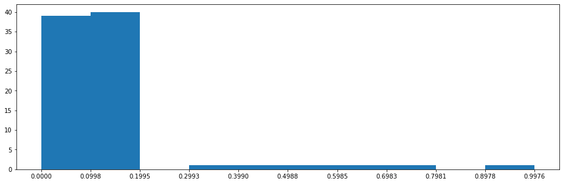

```python
fig = plt.figure(figsize=(16, 5))
n, bins, patches = plt.hist(mis_val_per_col_perc)
plt.xticks(bins)
plt.show()
```

```python
# Investigate patterns in the amount of missing data in each column.
# list top 10 missing values features from the highest to the least
mis_val_per_col_perc[:10]
```

```
TITEL_KZ          0.997576
AGER_TYP          0.769554
KK_KUNDENTYP      0.655967
KBA05_BAUMAX      0.534687
GEBURTSJAHR       0.440203
ALTER_HH          0.348137
KKK               0.177357
REGIOTYP          0.177357
W_KEIT_KIND_HH    0.166051
KBA05_ANTG1       0.149597
dtype: float64
```

```python
# Remove the outlier columns from the dataset. (You'll perform other data
# engineering tasks such as re-encoding and imputation later.)

# threshold in precentage
threshold = 0.25
top_k_missing_cols = mis_val_per_col_perc[mis_val_per_col_perc>threshold]
print ('The top {} columns with highest missing data to be removed from azdias dataset as follow\n{}'.format(len(top_k_missing_cols), top_k_missing_cols))
```

```
The top 6 columns with highest missing data to be removed from azdias dataset as follow
TITEL_KZ        0.997576
AGER_TYP        0.769554
KK_KUNDENTYP    0.655967
KBA05_BAUMAX    0.534687
GEBURTSJAHR     0.440203
ALTER_HH        0.348137
dtype: float64
```

```python
# Remove the outlier columns from the dataset. (You'll perform other data
top_k_missing_col_name = list (top_k_missing_cols.index)
azdias.drop(top_k_missing_col_name, axis=1, inplace=True)
```

```python
total_missing = azdias.isna().sum().sum()
print ('Total number of missing values after drop columns:', total_missing)
```

```
Total number of missing values after drop columns: 5035304
```

```python
azdias.head()
```

|  | ALTERSKATEGORIE_GROB | ANREDE_KZ | CJT_GESAMTTYP | FINANZ_MINIMALIST | FINANZ_SPARER | FINANZ_VORSORGER | FINANZ_ANLEGER | FINANZ_UNAUFFAELLIGER | FINANZ_HAUSBAUER | FINANZTYP | ... | PLZ8_ANTG1 | PLZ8_ANTG2 | PLZ8_ANTG3 | PLZ8_ANTG4 | PLZ8_BAUMAX | PLZ8_HHZ | PLZ8_GBZ | ARBEIT | ORTSGR_KLS9 | RELAT_AB |
| --- | --- | --- | --- | --- | --- | --- | --- | --- | --- | --- | --- | --- | --- | --- | --- | --- | --- | --- | --- | --- | --- |
| 0 | 2.0 | 1 | 2.0 | 3 | 4 | 3 | 5 | 5 | 3 | 4 | ... | NaN | NaN | NaN | NaN | NaN | NaN | NaN | NaN | NaN | NaN |
| 1 | 1.0 | 2 | 5.0 | 1 | 5 | 2 | 5 | 4 | 5 | 1 | ... | 2.0 | 3.0 | 2.0 | 1.0 | 1.0 | 5.0 | 4.0 | 3.0 | 5.0 | 4.0 |
| 2 | 3.0 | 2 | 3.0 | 1 | 4 | 1 | 2 | 3 | 5 | 1 | ... | 3.0 | 3.0 | 1.0 | 0.0 | 1.0 | 4.0 | 4.0 | 3.0 | 5.0 | 2.0 |
| 3 | 4.0 | 2 | 2.0 | 4 | 2 | 5 | 2 | 1 | 2 | 6 | ... | 2.0 | 2.0 | 2.0 | 0.0 | 1.0 | 3.0 | 4.0 | 2.0 | 3.0 | 3.0 |
| 4 | 3.0 | 1 | 5.0 | 4 | 3 | 4 | 1 | 3 | 2 | 5 | ... | 2.0 | 4.0 | 2.0 | 1.0 | 2.0 | 3.0 | 3.0 | 4.0 | 6.0 | 5.0 |

5 rows × 79 columns

#### Discussion 1.1.2: Assess Missing Data in Each Column

As we see above in the code we introduce threshold = 25%, which means any column(feature) > 25% missing data considered to be garbage and we delete it successfully

Top 6 columns(features) with missing values > 25 % from the highest to the least

| # | Features | missing Values |
| --- | --- | --- |
| 0 | TITEL_KZ | 0.997576 |
| 1 | AGER_TYP | 0.769554 |
| 2 | KK_KUNDENTYP | 0.655967 |
| 3 | KBA05_BAUMAX | 0.534687 |
| 4 | GEBURTSJAHR | 0.440203 |
| 5 | ALTER_HH | 0.348137 |

remaining features(columns) are 79

#### Step 1.1.3: Assess Missing Data in Each Row

Now, you'll perform a similar assessment for the rows of the dataset. How much data is missing in each row? As with the columns, you should see some groups of points that have a very different numbers of missing values. Divide the data into two subsets: one for data points that are above some threshold for missing values, and a second subset for points below that threshold.

In order to know what to do with the outlier rows, we should see if the distribution of data values on columns that are not missing data (or are missing very little data) are similar or different between the two groups. Select at least five of these columns and compare the distribution of values.

- You can use seaborn's [`countplot()`](https://seaborn.pydata.org/generated/seaborn.countplot.html) function to create a bar chart of code frequencies and matplotlib's [`subplot()`](https://matplotlib.org/api/_as_gen/matplotlib.pyplot.subplot.html) function to put bar charts for the two subplots side by side.
- To reduce repeated code, you might want to write a function that can perform this comparison, taking as one of its arguments a column to be compared.

Depending on what you observe in your comparison, this will have implications on how you approach your conclusions later in the analysis. If the distributions of non-missing features look similar between the data with many missing values and the data with few or no missing values, then we could argue that simply dropping those points from the analysis won't present a major issue. On the other hand, if the data with many missing values looks very different from the data with few or no missing values, then we should make a note on those data as special. We'll revisit these data later on. **Either way, you should continue your analysis for now using just the subset of the data with few or no missing values.**

```python
def total_miss_data_per_row(df: pd.DataFrame):
    return (df.isna().sum(axis=1)).sort_values(ascending=False)
```

```python
# How much data is missing in each row of the dataset?
# find_missing_data_per_col(azdias)
total_miss_val_per_row = total_miss_data_per_row(azdias)
print (total_miss_val_per_row)
```

```
732775    49
643174    49
472919    48
345274    47
299868    47
          ..
349047     0
349048     0
349049     0
349050     0
891220     0
Length: 891221, dtype: int64
```

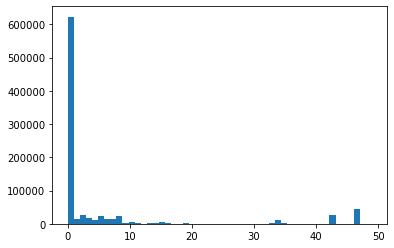

```python
plt.hist(total_miss_val_per_row, bins=50)
# total_miss_val_per_row.hist()
```

```python
def split_rows_with_na(df: pd.DataFrame, row_threshold: int):
    """
    Split DataFrame into two subsets based on the number of missing values 'nans' in each row
    that less than or equal 'row_threshold, and exceeds 'row_threshold'
    :param df: dataset
    :param row_threshold: e.g. 2 means first set max nans per row <= 2 and second set max nans per row > 2
    :return: df with all rows less or equal threshold e.g. row_threshold=2 means rows in the df will
    only have 2 missing values as max
    """
    x = df.isna().sum(axis=1)
    return df[x <= row_threshold], df[x > row_threshold]
```

```python
# Write code to divide the data into two subsets based on the number of missing
# values in each row.

# we can observe the histogram from above and determine the threshold what value to be
# How much exactly missing values per row that we can accept
row_threshold = 9

# azdias_gt garbage these records as it exceeds threshold
# azdias_ls use these records as it less or equal threshold
azdias_ls, azdias_gt = split_rows_with_na(azdias, row_threshold)
```

```python
azdias_ls.head()
```

|  | ALTERSKATEGORIE_GROB | ANREDE_KZ | CJT_GESAMTTYP | FINANZ_MINIMALIST | FINANZ_SPARER | FINANZ_VORSORGER | FINANZ_ANLEGER | FINANZ_UNAUFFAELLIGER | FINANZ_HAUSBAUER | FINANZTYP | ... | PLZ8_ANTG1 | PLZ8_ANTG2 | PLZ8_ANTG3 | PLZ8_ANTG4 | PLZ8_BAUMAX | PLZ8_HHZ | PLZ8_GBZ | ARBEIT | ORTSGR_KLS9 | RELAT_AB |
| --- | --- | --- | --- | --- | --- | --- | --- | --- | --- | --- | --- | --- | --- | --- | --- | --- | --- | --- | --- | --- | --- |
| 1 | 1.0 | 2 | 5.0 | 1 | 5 | 2 | 5 | 4 | 5 | 1 | ... | 2.0 | 3.0 | 2.0 | 1.0 | 1.0 | 5.0 | 4.0 | 3.0 | 5.0 | 4.0 |
| 2 | 3.0 | 2 | 3.0 | 1 | 4 | 1 | 2 | 3 | 5 | 1 | ... | 3.0 | 3.0 | 1.0 | 0.0 | 1.0 | 4.0 | 4.0 | 3.0 | 5.0 | 2.0 |
| 3 | 4.0 | 2 | 2.0 | 4 | 2 | 5 | 2 | 1 | 2 | 6 | ... | 2.0 | 2.0 | 2.0 | 0.0 | 1.0 | 3.0 | 4.0 | 2.0 | 3.0 | 3.0 |
| 4 | 3.0 | 1 | 5.0 | 4 | 3 | 4 | 1 | 3 | 2 | 5 | ... | 2.0 | 4.0 | 2.0 | 1.0 | 2.0 | 3.0 | 3.0 | 4.0 | 6.0 | 5.0 |
| 5 | 1.0 | 2 | 2.0 | 3 | 1 | 5 | 2 | 2 | 5 | 2 | ... | 2.0 | 3.0 | 1.0 | 1.0 | 1.0 | 5.0 | 5.0 | 2.0 | 3.0 | 3.0 |

5 rows × 79 columns

```python
# Observe number of missing per columns for 'azdias_ls'
azdias_ls.isna().sum()
```

```
ALTERSKATEGORIE_GROB    2596
ANREDE_KZ                  0
CJT_GESAMTTYP              0
FINANZ_MINIMALIST          0
FINANZ_SPARER              0
                        ...
PLZ8_HHZ                7783
PLZ8_GBZ                7783
ARBEIT                  3936
ORTSGR_KLS9             3850
RELAT_AB                3936
Length: 79, dtype: int64
```

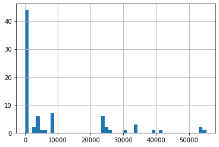

```python
azdias_ls.isna().sum().hist(bins=50)
```

```python
col_name_no_miss_and_miss = (azdias_ls.isna().sum()==0)
```

```python
# how many columns that have zero mising values
col_name_no_miss_and_miss.value_counts()
```

```
False    40
True     39
dtype: int64
```

```python
# get all columns name that equal 0 missing values for azdias_ls dataset (No missing values for these columns)
col_name_with_no_miss = col_name_no_miss_and_miss.loc[col_name_no_miss_and_miss==True].index
```

```python
col_name_with_no_miss = list (col_name_with_no_miss)
```

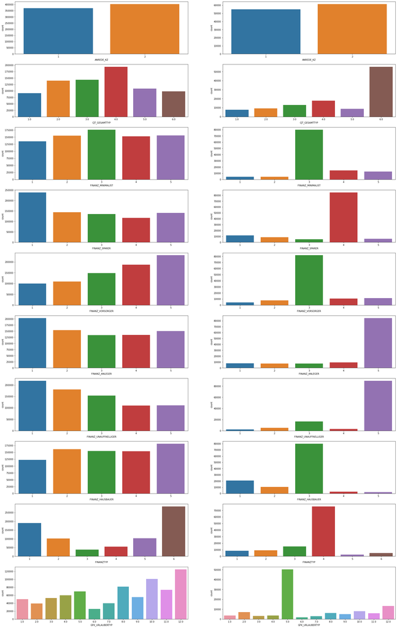

```python
# Compare the distribution of values for at least five columns where there are
# no or few missing values, between the two subsets.

nrows = len (col_name_with_no_miss[:10]) # get first 10 columns if exist
fig, axs = plt.subplots(nrows=nrows, ncols=2, figsize=(30, 50))
for i in range(nrows):
    sns.countplot( data=azdias_ls, x=col_name_with_no_miss[i], ax = axs[i][0] ) # azdias_ls missing values per row <= threshold
    sns.countplot( data=azdias_gt, x=col_name_with_no_miss[i], ax = axs[i][1] ) # azdias_gt missing values per row >  threshold
```

#### Discussion 1.1.3: Assess Missing Data in Each Row

As observation from above We divided our data into 2 groups:

[output not shown]

The left column above represents A

The right column above represents B

### Step 1.2: Select and Re-Encode Features

Checking for missing data isn't the only way in which you can prepare a dataset for analysis. Since the unsupervised learning techniques to be used will only work on data that is encoded numerically, you need to make a few encoding changes or additional assumptions to be able to make progress. In addition, while almost all of the values in the dataset are encoded using numbers, not all of them represent numeric values. Check the third column of the feature summary (`feat_info`) for a summary of types of measurement.

- For numeric and interval data, these features can be kept without changes.
- Most of the variables in the dataset are ordinal in nature. While ordinal values may technically be non-linear in spacing, make the simplifying assumption that the ordinal variables can be treated as being interval in nature (that is, kept without any changes).
- Special handling may be necessary for the remaining two variable types: categorical, and 'mixed'.

In the first two parts of this sub-step, you will perform an investigation of the categorical and mixed-type features and make a decision on each of them, whether you will keep, drop, or re-encode each. Then, in the last part, you will create a new data frame with only the selected and engineered columns.

Data wrangling is often the trickiest part of the data analysis process, and there's a lot of it to be done here. But stick with it: once you're done with this step, you'll be ready to get to the machine learning parts of the project!

```python
# How many features are there of each data type?
total_features_per_data_type = feat_info['type'].value_counts()
print (total_features_per_data_type)
```

```
ordinal        49
categorical    21
numeric         7
mixed           7
interval        1
Name: type, dtype: int64
```

#### Step 1.2.1: Re-Encode Categorical Features

For categorical data, you would ordinarily need to encode the levels as dummy variables. Depending on the number of categories, perform one of the following:

- For binary (two-level) categoricals that take numeric values, you can keep them without needing to do anything.
- There is one binary variable that takes on non-numeric values. For this one, you need to re-encode the values as numbers or create a dummy variable.
- For multi-level categoricals (three or more values), you can choose to encode the values using multiple dummy variables (e.g. via [OneHotEncoder](http://scikit-learn.org/stable/modules/generated/sklearn.preprocessing.OneHotEncoder.html)), or (to keep things straightforward) just drop them from the analysis. As always, document your choices in the Discussion section.

```python
# Assess categorical variables: which are binary, which are multi-level, and
# which one needs to be re-encoded?

# Re-encode categorical variable(s) to be kept in the analysis

# get available columns (not dropped) from the azdias
azdias_ls_feat = list (azdias_ls.columns)

all_categorical_features = feat_info[feat_info['type']=='categorical'  ]
azdias_ls_categorical_feat = all_categorical_features[all_categorical_features['attribute'].isin(azdias_ls_feat)]


print ( 'All categorical_features {}\nazdias_ls categorical features {} '.format(len(all_categorical_features), len(azdias_ls_categorical_feat)))
```

```
All categorical_features 21
azdias_ls categorical features 18
```

Let's dive in deep and focous on azdias_ls_categorical_features. Which are binary, which are multi-level, and which one needs to be re-encoded?

```python
binary_features = []
multi_features = []

for col in azdias_ls_categorical_feat.attribute:
    if (len(azdias_ls[col].value_counts().unique()) == 2):
        binary_features.append(col)
    else:
        multi_features.append(col)

print ('Categorical binary features:\n', binary_features, '\n')
print ('Categorical multi-features:\n', multi_features)
```

```
Categorical binary features:
 ['ANREDE_KZ', 'GREEN_AVANTGARDE', 'SOHO_KZ', 'VERS_TYP', 'OST_WEST_KZ']

Categorical multi-features:
 ['CJT_GESAMTTYP', 'FINANZTYP', 'GFK_URLAUBERTYP', 'LP_FAMILIE_FEIN', 'LP_FAMILIE_GROB', 'LP_STATUS_FEIN', 'LP_STATUS_GROB', 'NATIONALITAET_KZ', 'SHOPPER_TYP', 'ZABEOTYP', 'GEBAEUDETYP', 'CAMEO_DEUG_2015', 'CAMEO_DEU_2015']
```

```python
# Check binary_features
for feature in binary_features:
    print (feature, ' : ', azdias_ls[feature].unique())
```

```
ANREDE_KZ  :  [2 1]
GREEN_AVANTGARDE  :  [0 1]
SOHO_KZ  :  [1. 0.]
VERS_TYP  :  [ 2.  1. nan]
OST_WEST_KZ  :  ['W' 'O']
```

- 'OST_WEST_KZ' is binary variable takes non-numeric values need to be en-coded as follow:
  - O: East (GDR) encoded to be 0: East (GDR)
  - W: West (FRG) encoded to be 1: West (FRG)
- others ['ANREDE_KZ', GREEN_AVANTGARDE, SOHO_KZ, VERS_TYP]
  - their values are numerical (No further works needed)

```python
# Re-encode OST_WEST_KZ as we observed that values W and O can be re-encode to 0 and 1 respectively
azdias_ls['OST_WEST_KZ'].replace({'O': 0, 'W': 1}, inplace=True)
```

```python
azdias_ls['OST_WEST_KZ']
```

```
1         1
2         1
3         1
4         1
5         1
         ..
891216    1
891217    1
891218    1
891219    1
891220    1
Name: OST_WEST_KZ, Length: 774743, dtype: int64
```

```python
# Check multi_features
for feature in multi_features:
    print (feature, ' : ', azdias_ls[feature].unique())
```

```
CJT_GESAMTTYP  :  [5. 3. 2. 4. 1. 6.]
FINANZTYP  :  [1 6 5 2 4 3]
GFK_URLAUBERTYP  :  [10.  1.  5. 12.  9.  3.  8. 11.  4.  7.  2.  6.]
LP_FAMILIE_FEIN  :  [ 5.  1. nan 10.  2.  7. 11.  8.  4.  6.  9.  3.]
LP_FAMILIE_GROB  :  [ 3.  1. nan  5.  2.  4.]
LP_STATUS_FEIN  :  [ 2.  3.  9.  4.  1. 10.  5.  8.  6.  7.]
LP_STATUS_GROB  :  [1. 2. 4. 5. 3.]
NATIONALITAET_KZ  :  [ 1.  3.  2. nan]
SHOPPER_TYP  :  [ 3.  2.  1.  0. nan]
ZABEOTYP  :  [5 3 4 1 6 2]
GEBAEUDETYP  :  [8. 1. 3. 2. 6. 4. 5.]
CAMEO_DEUG_2015  :  ['8' '4' '2' '6' '1' '9' '5' '7' '3' nan]
CAMEO_DEU_2015  :  ['8A' '4C' '2A' '6B' '8C' '4A' '2D' '1A' '1E' '9D' '5C' '8B' '7A' '5D'
 '9E' '9B' '1B' '3D' nan '4E' '4B' '3C' '5A' '7B' '9A' '6D' '6E' '2C' '7C'
 '9C' '7D' '5E' '1D' '8D' '6C' '6A' '5B' '4D' '3A' '2B' '7E' '3B' '6F'
 '5F' '1C']
```

```python
print ('Number of features before drop multi-level categorical features:', len (azdias_ls.columns))
```

```
Number of features before drop multi-level categorical features: 79
```

```python
# drop multi-level categorical features
azdias_ls.drop(multi_features, axis=1, inplace=True)
```

```python
print ('Number of features after drop multi-level categorical features:', len (azdias_ls.columns))
```

```
Number of features after drop multi-level categorical features: 66
```

#### Discussion 1.2.1: Re-Encode Categorical Features

Categorical Features:

| # | Features | Binary/Multi | KEEP/DROP | Encode |
| --- | --- | --- | --- | --- |
| 0 | ANREDE_KZ | Binary | KEEP | NO ACTION |
| 1 | GREEN_AVANTGARDE | Binary | KEEP | NO ACTION |
| 2 | SOHO_KZ | Binary | KEEP | NO ACTION |
| 3 | VERS_TYP | Binary | KEEP | NO ACTION |
| 4 | OST_WEST_KZ | Binary | KEEP | replace({ 'O': 0, 'W': 1}) |
| 5 | CJT_GESAMTTYP | Multi | DROP | NA |
| 6 | FINANZTYP | Multi | DROP | NA |
| 7 | GFK_URLAUBERTYP | Multi | DROP | NA |
| 8 | LP_FAMILIE_FEIN | Multi | DROP | NA |
| 9 | LP_FAMILIE_GROB | Multi | DROP | NA |
| 10 | LP_STATUS_FEIN | Multi | DROP | NA |
| 11 | LP_STATUS_GROB | Multi | DROP | NA |
| 12 | NATIONALITAET_KZ | Multi | DROP | NA |
| 13 | SHOPPER_TYP | Multi | DROP | NA |
| 14 | ZABEOTYP | Multi | DROP | NA |
| 15 | GEBAEUDETYP | Multi | DROP | NA |
| 16 | CAMEO_DEUG_2015 | Multi | DROP | NA |
| 17 | CAMEO_DEU_2015 | Multi | DROP | NA |

#### Step 1.2.2: Engineer Mixed-Type Features

There are a handful of features that are marked as "mixed" in the feature summary that require special treatment in order to be included in the analysis. There are two in particular that deserve attention; the handling of the rest are up to your own choices:

- "PRAEGENDE_JUGENDJAHRE" combines information on three dimensions: generation by decade, movement (mainstream vs. avantgarde), and nation (east vs. west). While there aren't enough levels to disentangle east from west, you should create two new variables to capture the other two dimensions: an interval-type variable for decade, and a binary variable for movement.
- "CAMEO_INTL_2015" combines information on two axes: wealth and life stage. Break up the two-digit codes by their 'tens'-place and 'ones'-place digits into two new ordinal variables (which, for the purposes of this project, is equivalent to just treating them as their raw numeric values).
- If you decide to keep or engineer new features around the other mixed-type features, make sure you note your steps in the Discussion section.

Be sure to check `Data_Dictionary.md` for the details needed to finish these tasks.

- PRAEGENDE_JUGENDJAHRE: Dominating movement of person's youth (avantgarde vs. mainstream; east vs. west)
  - -1: unknown
  - 0: unknown
  - 1: 40s - war years (Mainstream, E+W)
  - 2: 40s - reconstruction years (Avantgarde, E+W)
  - 3: 50s - economic miracle (Mainstream, E+W)
  - 4: 50s - milk bar / Individualisation (Avantgarde, E+W)
  - 5: 60s - economic miracle (Mainstream, E+W)
  - 6: 60s - generation 68 / student protestors (Avantgarde, W)
  - 7: 60s - opponents to the building of the Wall (Avantgarde, E)
  - 8: 70s - family orientation (Mainstream, E+W)
  - 9: 70s - peace movement (Avantgarde, E+W)
  - 10: 80s - Generation Golf (Mainstream, W)
  - 11: 80s - ecological awareness (Avantgarde, W)
  - 12: 80s - FDJ / communist party youth organisation (Mainstream, E)
  - 13: 80s - Swords into ploughshares (Avantgarde, E)
  - 14: 90s - digital media kids (Mainstream, E+W)
  - 15: 90s - ecological awareness (Avantgarde, E+W)

```python
# Investigate "PRAEGENDE_JUGENDJAHRE" and engineer two new variables.

# Construct interval-type variable for decade (40, 50, 60, 70, 80, 90)
_40s = 0 #40s
_50s = 1 #50s
_60s = 2 #60s
_70s = 3 #70s
_80s = 4 #80s
_90s = 5 #90s
decade_map = {1:_40s, 2:_40s, 3:_50s, 4:_50s, 5:_60s, 6:_60s, 7:_60s, 8:_70s, 9:_70s, 10:_80s, 11:_80s, 12:_80s, 13:_80s,14:_90s,15:_90s }

azdias_ls['PRAEGENDE_DECADE'] = azdias_ls['PRAEGENDE_JUGENDJAHRE']
azdias_ls['PRAEGENDE_DECADE'].replace(decade_map, inplace=True)

# Construct binary variable for movement (mainstream vs. avantgarde)
ms = 0 # mainstream
av = 1 # avantgarde
decade_map = {1:ms, 2:av, 3:ms, 4:av, 5:ms, 6:av, 7:av, 8:ms, 9:av, 10:ms, 11:av, 12:ms, 13:av,14:ms,15:av }
azdias_ls['PRAEGENDE_MOVEMENT'] = azdias_ls['PRAEGENDE_JUGENDJAHRE']
azdias_ls['PRAEGENDE_MOVEMENT'].replace(decade_map, inplace=True)

# drop the column(feature) PRAEGENDE_JUGENDJAHRE as we derived 2 other features from
azdias_ls.drop('PRAEGENDE_JUGENDJAHRE', axis=1, inplace=True)
```

- CAMEO_INTL_2015: German CAMEO: Wealth / Life Stage Typology, mapped to international code
  - -1: unknown
  - 11: Wealthy Households - Pre-Family Couples & Singles
  - 12: Wealthy Households - Young Couples With Children
  - 13: Wealthy Households - Families With School Age Children
  - 14: Wealthy Households - Older Families & Mature Couples
  - 15: Wealthy Households - Elders In Retirement
  - 21: Prosperous Households - Pre-Family Couples & Singles
  - 22: Prosperous Households - Young Couples With Children
  - 23: Prosperous Households - Families With School Age Children
  - 24: Prosperous Households - Older Families & Mature Couples
  - 25: Prosperous Households - Elders In Retirement
  - 31: Comfortable Households - Pre-Family Couples & Singles
  - 32: Comfortable Households - Young Couples With Children
  - 33: Comfortable Households - Families With School Age Children
  - 34: Comfortable Households - Older Families & Mature Couples
  - 35: Comfortable Households - Elders In Retirement
  - 41: Less Affluent Households - Pre-Family Couples & Singles
  - 42: Less Affluent Households - Young Couples With Children
  - 43: Less Affluent Households - Families With School Age Children
  - 44: Less Affluent Households - Older Families & Mature Couples
  - 45: Less Affluent Households - Elders In Retirement
  - 51: Poorer Households - Pre-Family Couples & Singles
  - 52: Poorer Households - Young Couples With Children
  - 53: Poorer Households - Families With School Age Children
  - 54: Poorer Households - Older Families & Mature Couples
  - 55: Poorer Households - Elders In Retirement
  - XX: unknown

```python
# Investigate "CAMEO_INTL_2015" and engineer two new variables.
# Hint it's Object type comparison should be string

# Construct ordinal feature CAMEO_INTL_LIFE
a = 0 # Pre-Family Couples & Singles
b = 1 # Young Couples With Children
c = 2 # Families With School Age Children
d = 3 # Older Families & Mature Couples
e = 4 # Elders In Retirement
decade_map = {
              '11':a, '12':b, '13':c, '14':d, '15':e,
              '21':a, '22':b, '23':c, '24':d, '25':e,
              '31':a, '32':b, '33':c, '34':d, '35':e,
              '41':a, '42':b, '43':c, '44':d, '45':e,
              '51':a, '52':b, '53':c, '54':d, '55':e
             }

azdias_ls['CAMEO_INTL_LIFE'] = azdias_ls['CAMEO_INTL_2015']
azdias_ls['CAMEO_INTL_LIFE'].replace(decade_map, inplace=True)

# Construct ordinal feature CAMEO_INTL_WEALTH
a = 0 # Wealthy Households
b = 1 # Prosperous Households
c = 2 # Comfortable Households
d = 3 # Less Affluent Households
e = 4 # Poorer Households
decade_map = {
              '11':a, '12':a, '13':a, '14':a, '15':a,
              '21':b, '22':b, '23':b, '24':b, '25':b,
              '31':c, '32':c, '33':c, '34':c, '35':c,
              '41':d, '42':d, '43':d, '44':d, '45':d,
              '51':e, '52':e, '53':e, '54':e, '55':e,
             }
azdias_ls['CAMEO_INTL_WEALTH'] = azdias_ls['CAMEO_INTL_2015']
azdias_ls['CAMEO_INTL_WEALTH'].replace(decade_map, inplace=True)
# drop the column(feature) PRAEGENDE_JUGENDJAHRE as we derived 2 other features from
azdias_ls.drop('CAMEO_INTL_2015', axis=1, inplace=True)
```

As we knew earlier there are 7 mixed features

Let's drop the existed mixed feature in the 'azdias_ls' dataset

```python
# find all the mixed features
all_mixed_feat = feat_info[feat_info['type']=='mixed']['attribute']

# find all features in 'azdias_ls'
azdias_ls_feat = list (azdias_ls.columns)

# find the intersection
mixed_feat_to_remove = all_mixed_feat[all_mixed_feat.isin(azdias_ls_feat)]

# drop the intersection of them
azdias_ls.drop(mixed_feat_to_remove, axis=1, inplace=True)
```

```python
mixed_feat_to_remove
```

```
15    LP_LEBENSPHASE_FEIN
16    LP_LEBENSPHASE_GROB
56               WOHNLAGE
79            PLZ8_BAUMAX
Name: attribute, dtype: object
```

#### Discussion 1.2.2: Engineer Mixed-Type Features

Mixed-value feature:

| # | Feature | KEEP/DROP | Encode |
| --- | --- | --- | --- |
| 0 | LP_LEBENSPHASE_FEIN | DROP | NA |
| 1 | LP_LEBENSPHASE_GROB | DROP | NA |
| 2 | PRAEGENDE_JUGENDJAHRE | DROP | Special treatment PRAEGENDE_DECADE and PRAEGENDE_MOVEMENT are derived |
| 3 | WOHNLAGE | DROP | NA |
| 4 | CAMEO_INTL_2015 | DROP | Special treatment CAMEO_INTL_LIFE and CAMEO_INTL_WEALTH are derived |
| 5 | KBA05_BAUMAX | DROP | NA |
| 6 | PLZ8_BAUMAX | DROP | NA |

Hint:

KBA05_BAUMAX: dropped eariler due to their missing values > 25%

#### Step 1.2.3: Complete Feature Selection

In order to finish this step up, you need to make sure that your data frame now only has the columns that you want to keep. To summarize, the dataframe should consist of the following:

- All numeric, interval, and ordinal type columns from the original dataset.
- Binary categorical features (all numerically-encoded).
- Engineered features from other multi-level categorical features and mixed features.

Make sure that for any new columns that you have engineered, that you've excluded the original columns from the final dataset. Otherwise, their values will interfere with the analysis later on the project. For example, you should not keep "PRAEGENDE_JUGENDJAHRE", since its values won't be useful for the algorithm: only the values derived from it in the engineered features you created should be retained. As a reminder, your data should only be from **the subset with few or no missing values**.

```python
# Do whatever you need to in order to ensure that the dataframe only contains
# the columns that should be passed to the algorithm functions.
```

```python
azdias_ls.shape
```

```
(774743, 64)
```

```python
# If there are other re-engineering tasks you need to perform, make sure you
# take care of them here. (Dealing with missing data will come in step 2.1.)
azdias_ls.describe()
```

|  | ALTERSKATEGORIE_GROB | ANREDE_KZ | FINANZ_MINIMALIST | FINANZ_SPARER | FINANZ_VORSORGER | FINANZ_ANLEGER | FINANZ_UNAUFFAELLIGER | FINANZ_HAUSBAUER | GREEN_AVANTGARDE | HEALTH_TYP | ... | PLZ8_ANTG4 | PLZ8_HHZ | PLZ8_GBZ | ARBEIT | ORTSGR_KLS9 | RELAT_AB | PRAEGENDE_DECADE | PRAEGENDE_MOVEMENT | CAMEO_INTL_LIFE | CAMEO_INTL_WEALTH |
| --- | --- | --- | --- | --- | --- | --- | --- | --- | --- | --- | --- | --- | --- | --- | --- | --- | --- | --- | --- | --- | --- |
| count | 772147.000000 | 774743.000000 | 774743.000000 | 774743.000000 | 774743.000000 | 774743.000000 | 774743.000000 | 774743.000000 | 774743.000000 | 741323.000000 | ... | 766960.000000 | 766960.000000 | 766960.000000 | 770807.000000 | 770893.000000 | 770807.000000 | 749241.000000 | 749241.000000 | 771287.000000 | 771287.000000 |
| mean | 2.796903 | 1.521221 | 3.050652 | 2.710942 | 3.438778 | 2.837575 | 2.633012 | 3.144132 | 0.220033 | 2.203911 | ... | 0.699986 | 3.612779 | 3.379818 | 3.174345 | 5.306886 | 3.079348 | 3.324663 | 0.227522 | 1.870540 | 2.274813 |
| std | 1.019782 | 0.499550 | 1.377400 | 1.486386 | 1.377239 | 1.472501 | 1.393403 | 1.398325 | 0.414269 | 0.755091 | ... | 0.727384 | 0.973575 | 1.111673 | 0.996905 | 2.302338 | 1.359219 | 1.458284 | 0.419233 | 1.488003 | 1.465608 |
| min | 1.000000 | 1.000000 | 1.000000 | 1.000000 | 1.000000 | 1.000000 | 1.000000 | 1.000000 | 0.000000 | 1.000000 | ... | 0.000000 | 1.000000 | 1.000000 | 1.000000 | 1.000000 | 1.000000 | 0.000000 | 0.000000 | 0.000000 | 0.000000 |
| 25% | 2.000000 | 1.000000 | 2.000000 | 1.000000 | 2.000000 | 1.000000 | 1.000000 | 2.000000 | 0.000000 | 2.000000 | ... | 0.000000 | 3.000000 | 3.000000 | 3.000000 | 4.000000 | 2.000000 | 2.000000 | 0.000000 | 0.000000 | 1.000000 |
| 50% | 3.000000 | 2.000000 | 3.000000 | 3.000000 | 4.000000 | 3.000000 | 2.000000 | 3.000000 | 0.000000 | 2.000000 | ... | 1.000000 | 4.000000 | 3.000000 | 3.000000 | 5.000000 | 3.000000 | 3.000000 | 0.000000 | 2.000000 | 3.000000 |
| 75% | 4.000000 | 2.000000 | 4.000000 | 4.000000 | 5.000000 | 4.000000 | 4.000000 | 4.000000 | 0.000000 | 3.000000 | ... | 1.000000 | 4.000000 | 4.000000 | 4.000000 | 7.000000 | 4.000000 | 5.000000 | 0.000000 | 3.000000 | 4.000000 |
| max | 4.000000 | 2.000000 | 5.000000 | 5.000000 | 5.000000 | 5.000000 | 5.000000 | 5.000000 | 1.000000 | 3.000000 | ... | 2.000000 | 5.000000 | 5.000000 | 5.000000 | 9.000000 | 5.000000 | 5.000000 | 1.000000 | 4.000000 | 4.000000 |

8 rows × 64 columns

As we can see from the above we have 64 columns(features) and all of them appeared in the describe()

### Step 1.3: Create a Cleaning Function

Even though you've finished cleaning up the general population demographics data, it's important to look ahead to the future and realize that you'll need to perform the same cleaning steps on the customer demographics data. In this substep, complete the function below to execute the main feature selection, encoding, and re-engineering steps you performed above. Then, when it comes to looking at the customer data in Step 3, you can just run this function on that DataFrame to get the trimmed dataset in a single step.

```python
def clean_data(df: pd.DataFrame) -> pd.DataFrame:
    """
    Perform feature trimming, re-encoding, and engineering for demographics
    data

    INPUT: Demographics DataFrame
    OUTPUT: Trimmed and cleaned demographics DataFrame
    """

    # Put in code here to execute all main cleaning steps:
    # convert missing value codes into NaNs, ...
    df = find_mis_vals_convert_to_nans(df)

    # select, re-encode, and engineer column values.
    df['OST_WEST_KZ'].replace({'O': 0, 'W': 1}, inplace=True)


    # Construct interval-type variable for decade (40, 50, 60, 70, 80, 90)
    _40s = 0 #40s
    _50s = 1 #50s
    _60s = 2 #60s
    _70s = 3 #70s
    _80s = 4 #80s
    _90s = 5 #90s
    decade_map = {1:_40s, 2:_40s, 3:_50s, 4:_50s, 5:_60s, 6:_60s, 7:_60s, 8:_70s, 9:_70s, 10:_80s, 11:_80s, 12:_80s, 13:_80s,14:_90s,15:_90s }
    df['PRAEGENDE_DECADE'] = df['PRAEGENDE_JUGENDJAHRE']
    df['PRAEGENDE_DECADE'].replace(decade_map, inplace=True)

    # Construct binary variable for movement (mainstream vs. avantgarde)
    ms = 0 # mainstream
    av = 1 # avantgarde
    decade_map = {1:ms, 2:av, 3:ms, 4:av, 5:ms, 6:av, 7:av, 8:ms, 9:av, 10:ms, 11:av, 12:ms, 13:av,14:ms,15:av }
    df['PRAEGENDE_MOVEMENT'] = df['PRAEGENDE_JUGENDJAHRE']
    df['PRAEGENDE_MOVEMENT'].replace(decade_map, inplace=True)
    # we will drop the column(feature) PRAEGENDE_JUGENDJAHRE at the end as we derived 2 other features from


    # Construct ordinal feature CAMEO_INTL_LIFE
    a = 0 # Pre-Family Couples & Singles
    b = 1 # Young Couples With Children
    c = 2 # Families With School Age Children
    d = 3 # Older Families & Mature Couples
    e = 4 # Elders In Retirement
    decade_map = {
                  '11':a, '12':b, '13':c, '14':d, '15':e,
                  '21':a, '22':b, '23':c, '24':d, '25':e,
                  '31':a, '32':b, '33':c, '34':d, '35':e,
                  '41':a, '42':b, '43':c, '44':d, '45':e,
                  '51':a, '52':b, '53':c, '54':d, '55':e
                 }
    df['CAMEO_INTL_LIFE'] = df['CAMEO_INTL_2015']
    df['CAMEO_INTL_LIFE'].replace(decade_map, inplace=True)

    # Construct ordinal feature CAMEO_INTL_WEALTH
    a = 0 # Wealthy Households
    b = 1 # Prosperous Households
    c = 2 # Comfortable Households
    d = 3 # Less Affluent Households
    e = 4 # Poorer Households
    decade_map = {
                  '11':a, '12':a, '13':a, '14':a, '15':a,
                  '21':b, '22':b, '23':b, '24':b, '25':b,
                  '31':c, '32':c, '33':c, '34':c, '35':c,
                  '41':d, '42':d, '43':d, '44':d, '45':d,
                  '51':e, '52':e, '53':e, '54':e, '55':e,
                 }
    df['CAMEO_INTL_WEALTH'] = df['CAMEO_INTL_2015']
    df['CAMEO_INTL_WEALTH'].replace(decade_map, inplace=True)
    # drop the column(feature) PRAEGENDE_JUGENDJAHRE at the end as we derived 2 other features from

    # drop columns and records
    col_to_removed = ['TITEL_KZ', 'AGER_TYP', 'KK_KUNDENTYP', 'KBA05_BAUMAX', 'GEBURTSJAHR', 'ALTER_HH'] + multi_features + all_mixed_feat.values.tolist()
    df.drop(col_to_removed, axis=1, inplace=True)
    df, _ = split_rows_with_na(df, row_threshold=row_threshold )

    return df
```

## Step 2: Feature Transformation

### Step 2.1: Apply Feature Scaling

Before we apply dimensionality reduction techniques to the data, we need to perform feature scaling so that the principal component vectors are not influenced by the natural differences in scale for features. Starting from this part of the project, you'll want to keep an eye on the [API reference page for sklearn](http://scikit-learn.org/stable/modules/classes.html) to help you navigate to all of the classes and functions that you'll need. In this substep, you'll need to check the following:

- sklearn requires that data not have missing values in order for its estimators to work properly. So, before applying the scaler to your data, make sure that you've cleaned the DataFrame of the remaining missing values. This can be as simple as just removing all data points with missing data, or applying an [Imputer](https://scikit-learn.org/0.16/modules/generated/sklearn.preprocessing.Imputer.html) to replace all missing values. You might also try a more complicated procedure where you temporarily remove missing values in order to compute the scaling parameters before re-introducing those missing values and applying imputation. Think about how much missing data you have and what possible effects each approach might have on your analysis, and justify your decision in the discussion section below.
- For the actual scaling function, a [StandardScaler](http://scikit-learn.org/stable/modules/generated/sklearn.preprocessing.StandardScaler.html) instance is suggested, scaling each feature to mean 0 and standard deviation 1.
- For these classes, you can make use of the `.fit_transform()` method to both fit a procedure to the data as well as apply the transformation to the data at the same time. Don't forget to keep the fit sklearn objects handy, since you'll be applying them to the customer demographics data towards the end of the project.

```python
total_missing = azdias_ls.isna().sum().sum()
print ('Total number of missing data {}'.format(total_missing))
```

```
Total number of missing data 510438
```

```python
miss_cols = (azdias_ls.isna().sum()>0)
```

```python
miss_cols
```

```
ALTERSKATEGORIE_GROB     True
ANREDE_KZ               False
FINANZ_MINIMALIST       False
FINANZ_SPARER           False
FINANZ_VORSORGER        False
                        ...
RELAT_AB                 True
PRAEGENDE_DECADE         True
PRAEGENDE_MOVEMENT       True
CAMEO_INTL_LIFE          True
CAMEO_INTL_WEALTH        True
Length: 64, dtype: bool
```

```python
miss_cols = miss_cols[miss_cols==True].index.tolist()
```

```python
miss_cols
```

```
['ALTERSKATEGORIE_GROB',
 'HEALTH_TYP',
 'VERS_TYP',
 'W_KEIT_KIND_HH',
 'ANZ_HAUSHALTE_AKTIV',
 'ANZ_HH_TITEL',
 'KONSUMNAEHE',
 'KBA05_ANTG1',
 'KBA05_ANTG2',
 'KBA05_ANTG3',
 'KBA05_ANTG4',
 'KBA05_GBZ',
 'BALLRAUM',
 'EWDICHTE',
 'INNENSTADT',
 'GEBAEUDETYP_RASTER',
 'KKK',
 'MOBI_REGIO',
 'REGIOTYP',
 'KBA13_ANZAHL_PKW',
 'PLZ8_ANTG1',
 'PLZ8_ANTG2',
 'PLZ8_ANTG3',
 'PLZ8_ANTG4',
 'PLZ8_HHZ',
 'PLZ8_GBZ',
 'ARBEIT',
 'ORTSGR_KLS9',
 'RELAT_AB',
 'PRAEGENDE_DECADE',
 'PRAEGENDE_MOVEMENT',
 'CAMEO_INTL_LIFE',
 'CAMEO_INTL_WEALTH']
```

```python
nrows = len(miss_cols) # get first 10 columns if exist
fig, axs = plt.subplots(nrows=nrows, ncols=1, figsize=(5, 6*nrows))
for i in range(nrows):
    sns.countplot( data=azdias_ls, x=miss_cols[i], ax = axs[i] )
```

[figure not shown]

```python
total_missing_cols = azdias_ls.isna().sum().sort_values(ascending=False)
```

```python
total_missing_cols[:40]
```

```
W_KEIT_KIND_HH           55257
KKK                      54136
REGIOTYP                 54136
HEALTH_TYP               33420
VERS_TYP                 33420
PRAEGENDE_MOVEMENT       25502
PRAEGENDE_DECADE         25502
KBA05_ANTG1              24201
KBA05_ANTG2              24201
KBA05_ANTG3              24201
KBA05_ANTG4              24201
KBA05_GBZ                24201
MOBI_REGIO               24201
PLZ8_ANTG1                7783
PLZ8_ANTG3                7783
PLZ8_ANTG2                7783
PLZ8_ANTG4                7783
PLZ8_HHZ                  7783
PLZ8_GBZ                  7783
ANZ_HAUSHALTE_AKTIV       5651
KBA13_ANZAHL_PKW          5483
ARBEIT                    3936
RELAT_AB                  3936
ORTSGR_KLS9               3850
CAMEO_INTL_LIFE           3456
CAMEO_INTL_WEALTH         3456
ANZ_HH_TITEL              3163
ALTERSKATEGORIE_GROB      2596
INNENSTADT                 526
EWDICHTE                   526
BALLRAUM                   526
KONSUMNAEHE                 51
GEBAEUDETYP_RASTER           5
ANREDE_KZ                    0
SEMIO_LUST                   0
FINANZ_MINIMALIST            0
FINANZ_SPARER                0
FINANZ_VORSORGER             0
FINANZ_ANLEGER               0
FINANZ_UNAUFFAELLIGER        0
dtype: int64
```

```python
start = time.time()
iterative_imp = IterativeImputer(random_state=42)
cleaned_data =  iterative_imp.fit_transform(azdias_ls)
cleaned_data = pd.DataFrame (cleaned_data, columns=azdias_ls.columns)
end = time.time()
print ('The time execution of imputing is :', end-start)
```

```
The time execution of imputing is : 1837.5204484462738
```

```python
total_missing = cleaned_data.isna().sum().sum()
print ('Total number of missing data after cleaned_data {}'.format(total_missing))
```

```
Total number of missing data after cleaned_data 0
```

```python
# Apply Standard Scaler
scaler = StandardScaler()
cleaned_data = pd.DataFrame (scaler.fit_transform(cleaned_data), columns=azdias_ls.columns)
```

```python
cleaned_data.head()
```

|  | ALTERSKATEGORIE_GROB | ANREDE_KZ | FINANZ_MINIMALIST | FINANZ_SPARER | FINANZ_VORSORGER | FINANZ_ANLEGER | FINANZ_UNAUFFAELLIGER | FINANZ_HAUSBAUER | GREEN_AVANTGARDE | HEALTH_TYP | ... | PLZ8_ANTG4 | PLZ8_HHZ | PLZ8_GBZ | ARBEIT | ORTSGR_KLS9 | RELAT_AB | PRAEGENDE_DECADE | PRAEGENDE_MOVEMENT | CAMEO_INTL_LIFE | CAMEO_INTL_WEALTH |
| --- | --- | --- | --- | --- | --- | --- | --- | --- | --- | --- | --- | --- | --- | --- | --- | --- | --- | --- | --- | --- | --- |
| 0 | -1.764180 | 0.958422 | -1.488785 | 1.540017 | -1.044684 | 1.468541 | 0.981043 | 1.327209 | -0.531136 | 1.079485 | ... | 0.412107 | 1.427693 | 0.560029 | -0.173763 | -0.131247 | 0.678558 | 1.153354 | -0.531136 | -1.259923 | 1.178889 |
| 1 | 0.199938 | 0.958422 | -1.488785 | 0.867244 | -1.770775 | -0.568811 | 0.263375 | 1.327209 | 1.882757 | 1.079485 | ... | -0.966111 | 0.397929 | 0.560029 | -0.173763 | -0.131247 | -0.795498 | 1.153354 | 1.882757 | 0.759955 | -0.870433 |
| 2 | 1.181997 | 0.958422 | 0.689233 | -0.478302 | 1.133590 | -0.568811 | -1.171961 | -0.818216 | -0.531136 | -0.256887 | ... | -0.966111 | -0.631835 | 0.560029 | -1.178578 | -1.000747 | -0.058470 | -0.222141 | -0.531136 | -0.586631 | -1.553540 |
| 3 | 0.199938 | -1.043381 | 0.689233 | 0.194471 | 0.407498 | -1.247929 | 0.263375 | -0.818216 | -0.531136 | 1.079485 | ... | 0.412107 | -0.631835 | -0.342025 | 0.831052 | 0.303504 | 1.415586 | -0.222141 | -0.531136 | 0.086662 | 0.495782 |
| 4 | -1.764180 | 0.958422 | -0.036773 | -1.151076 | 1.133590 | -0.568811 | -0.454293 | 1.327209 | -0.531136 | 1.079485 | ... | 0.412107 | 1.427693 | 1.462084 | -1.178578 | -1.000747 | -0.058470 | -1.597635 | -0.531136 | 0.759955 | 1.178889 |

5 rows × 64 columns

```python
total_missing = cleaned_data.isna().sum().sum()
print ('Total number of missing data {}'.format(total_missing))
```

```
Total number of missing data 0
```

### Discussion 2.1: Apply Feature Scaling

We plot the distribution of data values on remaining missing columns to observe the nature of the data.

#### Deal with missing values:

A basic strategy to use incomplete datasets is to discard entire rows and/or columns containing missing values. However, this comes at the price of losing data which may be valuable. A better strategy is to impute the missing values (infer) from the known part of the data.A better strategy is to impute the missing values (infer) from the known part of the data.

Dealing with missing values have 2 main approachs

- Removing all data points with missing data
  - A basic strategy to use incomplete datasets is to discard entire rows and/or columns containing missing values
- Use fill technique - Imputer
  - A better strategy is to impute the missing values (infer) from the known part of the data.

We try to exploit 2 approaches by removing some of columns and records (step 1.1.2 & step 1.1.3) and fill others. It's kind of making a suitable mixture of 2 methods

So, it's time to choose the fill technique and it's a chance to discover and google more about various technique used to fill missing values and what the pros and cons for each one here are some prmoising techniques might be used.

- SimpleImputer: Simple and fast technique with option of filling missing value strategy ('mean', 'median', 'most_frequent', 'constant')
- KNNImputer: Each sample's missing values are imputed using the mean value from n_neighbors nearest neighbors found in the trainig set. Two sample are close if the features that neither is missing are close.
- Iterative Imputer: A strategy for imputing missing values by modeling each feature with missing values as a function of other features in a round-robin fashion.

and many others ....

We decided to go with Iterative Imputer to handle Nans for 33 features as it infer from other features in a round-robin fashion.

We observed all the columns are not scaled properly, which may lead to wrong outcomes. So to do this we will use sklearn Standard scaler using default parameters with_mean=True and with_std=True

### Step 2.2: Perform Dimensionality Reduction

On your scaled data, you are now ready to apply dimensionality reduction techniques.

- Use sklearn's [PCA](http://scikit-learn.org/stable/modules/generated/sklearn.decomposition.PCA.html) class to apply principal component analysis on the data, thus finding the vectors of maximal variance in the data. To start, you should not set any parameters (so all components are computed) or set a number of components that is at least half the number of features (so there's enough features to see the general trend in variability).
- Check out the ratio of variance explained by each principal component as well as the cumulative variance explained. Try plotting the cumulative or sequential values using matplotlib's [`plot()`](https://matplotlib.org/api/_as_gen/matplotlib.pyplot.plot.html) function. Based on what you find, select a value for the number of transformed features you'll retain for the clustering part of the project.
- Once you've made a choice for the number of components to keep, make sure you re-fit a PCA instance to perform the decided-on transformation.

```python
def plot_num_component_vs_variance(pca):
    '''
    Creates a scree plot associated with the principal components

    INPUT: pca - the result of instantian of PCA in scikit learn

    OUTPUT:
            None
    '''
    num_components=len(pca.explained_variance_ratio_)
    ind = np.arange(num_components)
    vals = pca.explained_variance_ratio_

    plt.figure(figsize=(10, 6))
    ax = plt.subplot(111)
    cumvals = np.cumsum(vals)
    ax.bar(ind, vals)
    ax.plot(ind, cumvals)
    for i in range(num_components):
        ax.annotate(r"%s%%" % ((str(vals[i]*100)[:4])), (ind[i]+0.2, vals[i]), va="bottom", ha="center", fontsize=12)

    ax.xaxis.set_tick_params(width=0)
    ax.yaxis.set_tick_params(width=2, length=12)

    ax.set_xlabel("Principal Component")
    ax.set_ylabel("Variance Explained (%)")
    plt.title('Explained Variance Per Principal Component')
```

```python
def plot_num_component_vs_variance2(pca):
    plt.plot(pca.explained_variance_ratio_)
    plt.xlabel('Number of components')
    plt.ylabel('Explained variance ratio')
```

```python
# Apply PCA to the data.
pca = PCA()
X_pca = pca.fit_transform(cleaned_data)
```

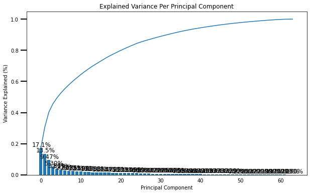

```python
# Investigate the variance accounted for by each principal component.
plot_num_component_vs_variance(pca)
```

```python
# Re-apply PCA to the data while selecting for number of components to retain.
# select num_features to be 0.6 from available features
num_features = int (0.6 * len(cleaned_data.columns))
pca = PCA(num_features)
X_pca = pca.fit_transform(cleaned_data)
```

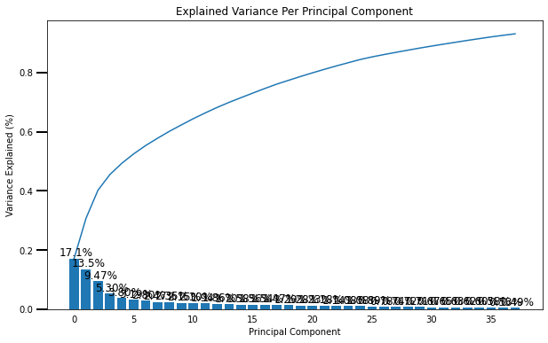

```python
plot_num_component_vs_variance(pca)
```

### Discussion 2.2: Perform Dimensionality Reduction

As much components we decide to keep the more variance accounted, but also we can do well with fewer components

I decide to go with 60% of available features which is 38 principle components to keep

### Step 2.3: Interpret Principal Components

Now that we have our transformed principal components, it's a nice idea to check out the weight of each variable on the first few components to see if they can be interpreted in some fashion.

As a reminder, each principal component is a unit vector that points in the direction of highest variance (after accounting for the variance captured by earlier principal components). The further a weight is from zero, the more the principal component is in the direction of the corresponding feature. If two features have large weights of the same sign (both positive or both negative), then increases in one tend expect to be associated with increases in the other. To contrast, features with different signs can be expected to show a negative correlation: increases in one variable should result in a decrease in the other.

- To investigate the features, you should map each weight to their corresponding feature name, then sort the features according to weight. The most interesting features for each principal component, then, will be those at the beginning and end of the sorted list. Use the data dictionary document to help you understand these most prominent features, their relationships, and what a positive or negative value on the principal component might indicate.
- You should investigate and interpret feature associations from the first three principal components in this substep. To help facilitate this, you should write a function that you can call at any time to print the sorted list of feature weights, for the *i*-th principal component. This might come in handy in the next step of the project, when you interpret the tendencies of the discovered clusters.

```python
# HINT: Try defining a function here or in a new cell that you can reuse in the
# other cells.
def feats_weight_by_component(pca_components_features: pd.DataFrame, comp_num: int, plot=False):
    """
    Returns selected component associated with weight for all features
    """
    if (comp_num >= len(pca_components_features)):
        raise Exception (' \'comp_num\' parameter larger than available components ')

    feats = pca_components_features.iloc[comp_num,:].sort_values(ascending=False)

    if plot:
        # visualize most 5 +ve prominent features and most 5 -ve prominent features
        plt_feats = list (feats[:5].index) + list (feats[-5:].index)
        pca_components_features[plt_feats].loc[comp_num].plot(kind='bar')
    return feats
```

```python
# convert numpy array components_ to pandas DataFrame
pca_components_features = pd.DataFrame(pca.components_, columns=list(azdias_ls.columns))
```

```python
pca_components_features
```

|  | ALTERSKATEGORIE_GROB | ANREDE_KZ | FINANZ_MINIMALIST | FINANZ_SPARER | FINANZ_VORSORGER | FINANZ_ANLEGER | FINANZ_UNAUFFAELLIGER | FINANZ_HAUSBAUER | GREEN_AVANTGARDE | HEALTH_TYP | ... | PLZ8_ANTG4 | PLZ8_HHZ | PLZ8_GBZ | ARBEIT | ORTSGR_KLS9 | RELAT_AB | PRAEGENDE_DECADE | PRAEGENDE_MOVEMENT | CAMEO_INTL_LIFE | CAMEO_INTL_WEALTH |
| --- | --- | --- | --- | --- | --- | --- | --- | --- | --- | --- | --- | --- | --- | --- | --- | --- | --- | --- | --- | --- | --- |
| 0 | -0.109460 | 0.008608 | -0.215644 | 0.137066 | -0.104706 | 0.061279 | 0.065189 | 0.166326 | -0.109546 | 0.025354 | ... | 0.221342 | 0.042415 | -0.168766 | 0.144985 | 0.198953 | 0.136965 | 0.092385 | -0.109546 | -0.124558 | 0.209151 |
| 1 | 0.263705 | 0.086847 | 0.076121 | -0.241027 | 0.236847 | -0.207950 | -0.230183 | 0.109653 | -0.011219 | -0.056724 | ... | 0.079878 | 0.011463 | -0.064628 | 0.060580 | 0.081195 | 0.058517 | -0.258583 | -0.011219 | 0.007035 | 0.065681 |
| 2 | 0.076520 | -0.369887 | 0.156887 | -0.104067 | 0.098928 | -0.187015 | -0.097137 | -0.046109 | 0.048713 | -0.011334 | ... | 0.043099 | 0.003949 | -0.036510 | 0.032658 | 0.044271 | 0.029823 | -0.107974 | 0.048713 | -0.008007 | 0.025227 |
| 3 | -0.041536 | 0.035714 | 0.066392 | -0.006011 | -0.015968 | -0.128016 | 0.080662 | -0.109399 | 0.396453 | 0.009969 | ... | 0.087759 | 0.141935 | 0.033033 | 0.053040 | 0.249814 | 0.094905 | 0.040356 | 0.396453 | 0.055711 | -0.123105 |
| 4 | -0.001192 | -0.005651 | -0.086852 | 0.007350 | 0.061500 | -0.036510 | 0.048449 | 0.089517 | -0.055568 | -0.017626 | ... | -0.019449 | 0.489726 | 0.404777 | -0.218356 | -0.092011 | -0.147777 | -0.030548 | -0.055568 | -0.023192 | 0.005369 |
| 5 | -0.003482 | 0.018159 | -0.033042 | 0.003555 | -0.031575 | 0.019472 | -0.030418 | 0.043863 | 0.001382 | -0.027593 | ... | 0.088986 | -0.035891 | -0.086271 | -0.169574 | -0.077671 | -0.207756 | 0.001749 | 0.001382 | 0.056433 | -0.070071 |
| 6 | 0.021661 | -0.060975 | 0.053004 | 0.051265 | -0.011990 | 0.072490 | 0.028969 | -0.180214 | -0.025817 | 0.220737 | ... | 0.051849 | 0.210419 | 0.121484 | -0.003079 | 0.100741 | 0.012788 | 0.100114 | -0.025817 | -0.073297 | 0.024766 |
| 7 | 0.150911 | -0.019458 | -0.074660 | 0.097367 | -0.141443 | 0.138347 | 0.031795 | 0.032416 | 0.016373 | -0.107329 | ... | 0.102694 | 0.087187 | -0.016503 | 0.038137 | -0.110405 | -0.020443 | 0.118245 | 0.016373 | -0.043790 | 0.076422 |
| 8 | 0.035677 | 0.097212 | 0.036510 | -0.078415 | 0.060724 | -0.007684 | -0.067886 | 0.051787 | 0.012569 | -0.489090 | ... | 0.033518 | 0.139434 | 0.077037 | 0.119264 | 0.062373 | 0.057415 | -0.109726 | 0.012569 | 0.023290 | 0.021899 |
| 9 | 0.119276 | 0.008211 | -0.145626 | 0.149488 | -0.031755 | 0.063817 | 0.263334 | 0.043997 | 0.113434 | -0.277022 | ... | -0.074990 | -0.225125 | -0.116743 | -0.320340 | -0.024024 | -0.117495 | 0.099977 | 0.113434 | -0.103779 | 0.020060 |
| 10 | -0.060937 | 0.004243 | 0.127363 | -0.149251 | 0.197536 | -0.170833 | -0.147219 | -0.128989 | -0.139802 | 0.155944 | ... | 0.022095 | -0.141449 | -0.124574 | -0.302042 | -0.090072 | -0.148526 | -0.092885 | -0.139802 | -0.163009 | 0.059302 |
| 11 | -0.094858 | 0.020095 | -0.075730 | -0.023197 | 0.081553 | 0.028583 | -0.091899 | 0.211351 | 0.137575 | 0.042293 | ... | -0.100323 | -0.013476 | 0.064521 | 0.170332 | -0.023184 | 0.172962 | -0.057830 | 0.137575 | 0.218991 | -0.002477 |
| 12 | 0.055033 | -0.021800 | 0.114248 | -0.009610 | -0.058244 | 0.003455 | 0.021345 | -0.208302 | -0.100533 | 0.039869 | ... | 0.029982 | 0.063911 | 0.008022 | 0.071026 | -0.022338 | 0.106826 | 0.027795 | -0.100533 | -0.183226 | 0.090949 |
| 13 | 0.024483 | -0.025816 | -0.066198 | 0.006091 | -0.008522 | -0.036883 | 0.013365 | 0.052459 | -0.249995 | -0.055345 | ... | -0.087988 | -0.035555 | 0.026704 | -0.086953 | 0.138431 | -0.238248 | 0.006916 | -0.249995 | 0.319654 | -0.226488 |
| 14 | -0.076382 | 0.038968 | 0.023061 | -0.014329 | -0.031692 | 0.122183 | -0.071062 | 0.086382 | 0.179087 | 0.030915 | ... | 0.166485 | 0.023303 | -0.123579 | -0.250878 | -0.068098 | -0.468419 | -0.035200 | 0.179087 | -0.006110 | -0.037800 |
| 15 | -0.013769 | 0.004564 | 0.004689 | -0.006650 | -0.001136 | 0.010841 | -0.015093 | 0.025788 | -0.007463 | -0.001116 | ... | 0.020987 | 0.009585 | -0.011983 | -0.015529 | -0.005985 | -0.044967 | -0.008257 | -0.007463 | 0.010366 | -0.008558 |
| 16 | 0.044103 | -0.008035 | 0.004333 | 0.041171 | -0.024624 | -0.011772 | 0.129635 | -0.210733 | 0.185961 | 0.036100 | ... | 0.018185 | -0.047433 | -0.023450 | -0.071258 | -0.020652 | 0.053567 | 0.047978 | 0.185961 | -0.105471 | 0.032033 |
| 17 | -0.077463 | 0.039188 | 0.086876 | -0.183970 | 0.211571 | -0.131815 | -0.178112 | 0.067993 | 0.091690 | -0.042829 | ... | 0.077715 | -0.003916 | -0.063399 | -0.091135 | -0.045409 | -0.050378 | -0.125608 | 0.091690 | 0.059307 | 0.027952 |
| 18 | 0.038111 | -0.012527 | -0.011550 | -0.012804 | 0.005396 | -0.019268 | -0.142671 | 0.086499 | 0.105308 | 0.107469 | ... | -0.135212 | 0.003509 | 0.123768 | 0.098627 | 0.064663 | -0.053876 | -0.005873 | 0.105308 | -0.579980 | 0.183024 |
| 19 | -0.032981 | 0.014337 | -0.029112 | 0.006656 | 0.058893 | -0.042623 | 0.092067 | 0.061404 | -0.237675 | -0.160169 | ... | 0.074946 | 0.017554 | -0.013154 | 0.005029 | -0.000079 | 0.163546 | -0.012526 | -0.237675 | 0.025890 | -0.062795 |
| 20 | -0.147170 | 0.064562 | -0.120423 | -0.050712 | 0.202218 | -0.021333 | 0.029016 | 0.237284 | 0.037753 | -0.338141 | ... | -0.054691 | -0.014859 | 0.031152 | 0.002502 | 0.030477 | 0.032319 | -0.101828 | 0.037753 | -0.264595 | 0.067685 |
| 21 | -0.037402 | 0.024510 | 0.022960 | -0.037799 | 0.044173 | -0.020784 | 0.014121 | -0.039391 | -0.020813 | -0.039277 | ... | -0.066590 | -0.011931 | 0.064932 | 0.082747 | 0.017927 | 0.231359 | -0.024755 | -0.020813 | 0.096126 | -0.097376 |
| 22 | -0.023711 | 0.024600 | 0.036283 | -0.001831 | 0.004360 | -0.021513 | -0.020380 | 0.008430 | -0.139641 | -0.035747 | ... | 0.090250 | 0.050181 | -0.037453 | -0.057260 | 0.039561 | -0.074711 | 0.002852 | -0.139641 | -0.387227 | 0.084059 |
| 23 | 0.069252 | -0.037104 | 0.038274 | 0.007289 | -0.038442 | -0.062738 | 0.065161 | -0.014454 | -0.041256 | -0.039268 | ... | -0.032226 | -0.002519 | 0.033810 | 0.054430 | -0.016853 | 0.051842 | -0.003590 | -0.041256 | -0.089360 | -0.006860 |
| 24 | -0.044083 | 0.030348 | -0.075958 | 0.076150 | -0.041460 | 0.133777 | 0.045829 | 0.041119 | 0.053831 | -0.230442 | ... | 0.011892 | 0.013614 | 0.004381 | -0.009766 | -0.080560 | -0.001022 | 0.035969 | 0.053831 | -0.031238 | 0.035505 |
| 25 | -0.054856 | 0.023846 | -0.171706 | 0.035423 | 0.170737 | 0.086596 | 0.071424 | 0.311510 | -0.022815 | 0.498136 | ... | -0.011944 | -0.012615 | 0.000612 | 0.026916 | -0.031843 | 0.095481 | -0.066693 | -0.022815 | -0.068086 | -0.112383 |
| 26 | 0.018428 | -0.104822 | 0.009602 | 0.030830 | 0.019057 | 0.030090 | 0.007441 | -0.006505 | 0.039138 | 0.111740 | ... | -0.021105 | -0.009744 | -0.004224 | 0.014404 | 0.011853 | -0.033034 | 0.028761 | 0.039138 | 0.055449 | 0.026884 |
| 27 | 0.025132 | 0.008074 | -0.112210 | 0.006972 | 0.040243 | 0.031514 | -0.031933 | 0.130111 | 0.090467 | 0.090778 | ... | -0.287296 | -0.097682 | 0.084311 | 0.056809 | -0.029722 | -0.082030 | -0.045977 | 0.090467 | 0.117877 | 0.212540 |
| 28 | -0.022381 | 0.007890 | 0.003596 | -0.021393 | -0.025640 | 0.004990 | -0.025301 | 0.014280 | 0.015681 | 0.030734 | ... | -0.279635 | -0.102904 | 0.119732 | 0.029363 | -0.014445 | -0.124899 | -0.005974 | 0.015681 | 0.029572 | 0.160329 |
| 29 | 0.097762 | -0.049055 | -0.201753 | 0.006893 | 0.057750 | -0.038053 | 0.121696 | 0.304323 | 0.041531 | 0.142370 | ... | 0.266786 | 0.074576 | -0.082242 | -0.134275 | 0.093978 | 0.017314 | -0.048345 | 0.041531 | 0.073099 | -0.050156 |
| 30 | -0.060443 | 0.039448 | 0.085182 | 0.005585 | 0.033917 | -0.027971 | -0.102309 | -0.201092 | 0.018468 | -0.028409 | ... | 0.175253 | 0.021699 | -0.073917 | -0.022540 | 0.031907 | 0.024398 | -0.008773 | 0.018468 | 0.115386 | 0.140311 |
| 31 | 0.003319 | -0.024451 | -0.015810 | 0.019504 | 0.055196 | 0.019164 | -0.066541 | 0.026125 | 0.015214 | -0.061173 | ... | -0.027944 | -0.007166 | -0.014482 | -0.026332 | -0.020485 | -0.001872 | 0.031484 | 0.015214 | 0.104195 | 0.171992 |
| 32 | -0.038725 | 0.055154 | 0.056553 | -0.004427 | -0.081374 | -0.008555 | -0.033312 | -0.176016 | -0.054568 | 0.029755 | ... | -0.102962 | 0.019043 | 0.045040 | -0.010509 | 0.006469 | -0.083204 | 0.018971 | -0.054568 | 0.017063 | 0.033581 |
| 33 | 0.018409 | -0.014159 | 0.063681 | 0.058084 | -0.073290 | 0.117721 | 0.041394 | -0.104468 | -0.070760 | -0.060081 | ... | -0.018398 | -0.047768 | -0.037859 | 0.060806 | -0.037002 | 0.098717 | -0.006145 | -0.070760 | -0.138038 | -0.210264 |
| 34 | 0.012420 | -0.039565 | 0.075348 | -0.020040 | -0.038888 | -0.074640 | 0.023731 | -0.001484 | -0.019441 | -0.063554 | ... | -0.112636 | 0.029140 | 0.059181 | 0.027167 | 0.063665 | -0.114531 | -0.030964 | -0.019441 | -0.075040 | -0.145839 |
| 35 | -0.062322 | 0.026082 | 0.093441 | 0.029726 | -0.058281 | -0.046638 | 0.119451 | -0.175465 | -0.007007 | 0.000162 | ... | 0.059941 | 0.021462 | 0.003675 | 0.027827 | -0.082843 | -0.035251 | -0.010658 | -0.007007 | 0.238493 | 0.546054 |
| 36 | -0.001888 | -0.043563 | -0.012413 | -0.100073 | -0.197140 | -0.352217 | 0.371440 | 0.101592 | -0.019267 | 0.025371 | ... | -0.042065 | -0.009733 | 0.009321 | 0.036850 | 0.121016 | -0.142442 | -0.063107 | -0.019267 | 0.036835 | 0.228671 |
| 37 | -0.042791 | -0.028869 | -0.021776 | 0.006589 | -0.000777 | -0.109824 | 0.008918 | 0.022264 | -0.029923 | -0.088181 | ... | 0.017292 | 0.055803 | 0.032638 | 0.061406 | 0.320349 | -0.250411 | 0.054631 | -0.029923 | -0.047932 | -0.073653 |

38 rows × 64 columns

```
PLZ8_ANTG3            0.228537
PLZ8_ANTG4            0.221342
CAMEO_INTL_WEALTH     0.209151
HH_EINKOMMEN_SCORE    0.205548
ORTSGR_KLS9           0.198953
                        ...
FINANZ_MINIMALIST    -0.215644
KBA05_GBZ            -0.222229
PLZ8_ANTG1           -0.227565
KBA05_ANTG1          -0.229304
MOBI_REGIO           -0.246604
Name: 0, Length: 64, dtype: float64
```

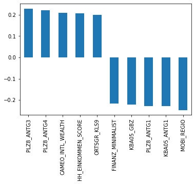

```python
# Map weights for the first principal component to corresponding feature names
# and then print the linked values, sorted by weight.
com_ = 0
feats_weight_by_component(pca_components_features, com_, plot=True)
```

```
ALTERSKATEGORIE_GROB    0.263705
FINANZ_VORSORGER        0.236847
SEMIO_ERL               0.231126
SEMIO_LUST              0.185297
RETOURTYP_BK_S          0.164663
                          ...
SEMIO_PFLICHT          -0.232606
SEMIO_TRADV            -0.233742
FINANZ_SPARER          -0.241027
SEMIO_REL              -0.257894
PRAEGENDE_DECADE       -0.258583
Name: 1, Length: 64, dtype: float64
```

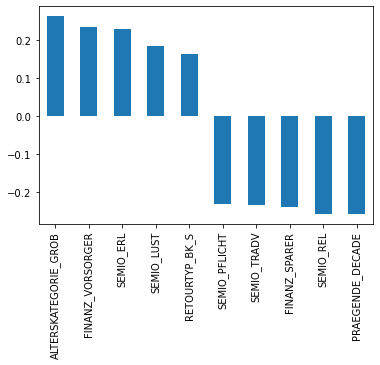

```python
# Map weights for the second principal component to corresponding feature names
# and then print the linked values, sorted by weight.
com_ = 1
feats_weight_by_component(pca_components_features, com_, plot=True)
```

```
SEMIO_VERT           0.346814
SEMIO_SOZ            0.264141
SEMIO_FAM            0.251261
SEMIO_KULT           0.235899
FINANZ_MINIMALIST    0.156887
                       ...
SEMIO_RAT           -0.216191
SEMIO_KRIT          -0.274924
SEMIO_DOM           -0.314273
SEMIO_KAEM          -0.338638
ANREDE_KZ           -0.369887
Name: 2, Length: 64, dtype: float64
```

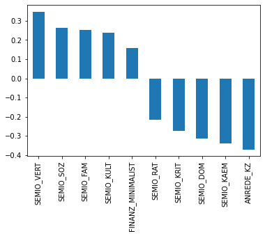

```python
# Map weights for the third principal component to corresponding feature names
# and then print the linked values, sorted by weight.
com_ = 2
feats_weight_by_component(pca_components_features, com_, plot=True)
```

```python
def pca_results(full_dataset, pca):
    '''
	Create a DataFrame of the PCA results
	Includes dimension feature weights and explained variance
	Visualizes the PCA results
	'''

    # Dimension indexing
    dimensions = dimensions = ['Dimension {}'.format(i) for i in range(1, len(pca.components_) + 1)]

    # PCA components
    components = pd.DataFrame(np.round(pca.components_, 4), columns=full_dataset.keys())
    components.index = dimensions

    # PCA explained variance
    ratios = pca.explained_variance_ratio_.reshape(len(pca.components_), 1)
    variance_ratios = pd.DataFrame(np.round(ratios, 4), columns=['Explained Variance'])
    variance_ratios.index = dimensions

    # Create a bar plot visualization
    fig, ax = plt.subplots(figsize=(56, 32))

    # Plot the feature weights as a function of the components
    components.plot(ax=ax, kind='bar');
    ax.set_ylabel("Feature Weights")
    ax.set_xticklabels(dimensions, rotation=0)

    # Display the explained variance ratios
    for i, ev in enumerate(pca.explained_variance_ratio_):
        ax.text(i - 0.40, ax.get_ylim()[1] + 0.05, "Explained Variance\n          %.4f" % (ev))

    # Return a concatenated DataFrame
    return pd.concat([variance_ratios, components], axis=1)
```

|  | Explained Variance | ALTERSKATEGORIE_GROB | ANREDE_KZ | FINANZ_MINIMALIST | FINANZ_SPARER | FINANZ_VORSORGER | FINANZ_ANLEGER | FINANZ_UNAUFFAELLIGER | FINANZ_HAUSBAUER | GREEN_AVANTGARDE | ... | PLZ8_ANTG4 | PLZ8_HHZ | PLZ8_GBZ | ARBEIT | ORTSGR_KLS9 | RELAT_AB | PRAEGENDE_DECADE | PRAEGENDE_MOVEMENT | CAMEO_INTL_LIFE | CAMEO_INTL_WEALTH |
| --- | --- | --- | --- | --- | --- | --- | --- | --- | --- | --- | --- | --- | --- | --- | --- | --- | --- | --- | --- | --- | --- |
| Dimension 1 | 0.1715 | -0.1095 | 0.0086 | -0.2156 | 0.1371 | -0.1047 | 0.0613 | 0.0652 | 0.1663 | -0.1095 | ... | 0.2213 | 0.0424 | -0.1688 | 0.1450 | 0.1990 | 0.1370 | 0.0924 | -0.1095 | -0.1246 | 0.2092 |
| Dimension 2 | 0.1357 | 0.2637 | 0.0868 | 0.0761 | -0.2410 | 0.2368 | -0.2080 | -0.2302 | 0.1097 | -0.0112 | ... | 0.0799 | 0.0115 | -0.0646 | 0.0606 | 0.0812 | 0.0585 | -0.2586 | -0.0112 | 0.0070 | 0.0657 |
| Dimension 3 | 0.0948 | 0.0765 | -0.3699 | 0.1569 | -0.1041 | 0.0989 | -0.1870 | -0.0971 | -0.0461 | 0.0487 | ... | 0.0431 | 0.0039 | -0.0365 | 0.0327 | 0.0443 | 0.0298 | -0.1080 | 0.0487 | -0.0080 | 0.0252 |
| Dimension 4 | 0.0531 | -0.0415 | 0.0357 | 0.0664 | -0.0060 | -0.0160 | -0.1280 | 0.0807 | -0.1094 | 0.3965 | ... | 0.0878 | 0.1419 | 0.0330 | 0.0530 | 0.2498 | 0.0949 | 0.0404 | 0.3965 | 0.0557 | -0.1231 |
| Dimension 5 | 0.0381 | -0.0012 | -0.0057 | -0.0869 | 0.0074 | 0.0615 | -0.0365 | 0.0484 | 0.0895 | -0.0556 | ... | -0.0194 | 0.4897 | 0.4048 | -0.2184 | -0.0920 | -0.1478 | -0.0305 | -0.0556 | -0.0232 | 0.0054 |
| Dimension 6 | 0.0319 | -0.0035 | 0.0182 | -0.0330 | 0.0036 | -0.0316 | 0.0195 | -0.0304 | 0.0439 | 0.0014 | ... | 0.0890 | -0.0359 | -0.0863 | -0.1696 | -0.0777 | -0.2078 | 0.0017 | 0.0014 | 0.0564 | -0.0701 |
| Dimension 7 | 0.0281 | 0.0217 | -0.0610 | 0.0530 | 0.0513 | -0.0120 | 0.0725 | 0.0290 | -0.1802 | -0.0258 | ... | 0.0518 | 0.2104 | 0.1215 | -0.0031 | 0.1007 | 0.0128 | 0.1001 | -0.0258 | -0.0733 | 0.0248 |
| Dimension 8 | 0.0247 | 0.1509 | -0.0195 | -0.0747 | 0.0974 | -0.1414 | 0.1383 | 0.0318 | 0.0324 | 0.0164 | ... | 0.1027 | 0.0872 | -0.0165 | 0.0381 | -0.1104 | -0.0204 | 0.1182 | 0.0164 | -0.0438 | 0.0764 |
| Dimension 9 | 0.0236 | 0.0357 | 0.0972 | 0.0365 | -0.0784 | 0.0607 | -0.0077 | -0.0679 | 0.0518 | 0.0126 | ... | 0.0335 | 0.1394 | 0.0770 | 0.1193 | 0.0624 | 0.0574 | -0.1097 | 0.0126 | 0.0233 | 0.0219 |
| Dimension 10 | 0.0215 | 0.1193 | 0.0082 | -0.1456 | 0.1495 | -0.0318 | 0.0638 | 0.2633 | 0.0440 | 0.1134 | ... | -0.0750 | -0.2251 | -0.1167 | -0.3203 | -0.0240 | -0.1175 | 0.1000 | 0.1134 | -0.1038 | 0.0201 |
| Dimension 11 | 0.0211 | -0.0609 | 0.0042 | 0.1274 | -0.1493 | 0.1975 | -0.1708 | -0.1472 | -0.1290 | -0.1398 | ... | 0.0221 | -0.1414 | -0.1246 | -0.3020 | -0.0901 | -0.1485 | -0.0929 | -0.1398 | -0.1630 | 0.0593 |
| Dimension 12 | 0.0195 | -0.0949 | 0.0201 | -0.0757 | -0.0232 | 0.0816 | 0.0286 | -0.0919 | 0.2114 | 0.1376 | ... | -0.1003 | -0.0135 | 0.0645 | 0.1703 | -0.0232 | 0.1730 | -0.0578 | 0.1376 | 0.2190 | -0.0025 |
| Dimension 13 | 0.0186 | 0.0550 | -0.0218 | 0.1142 | -0.0096 | -0.0582 | 0.0035 | 0.0213 | -0.2083 | -0.1005 | ... | 0.0300 | 0.0639 | 0.0080 | 0.0710 | -0.0223 | 0.1068 | 0.0278 | -0.1005 | -0.1832 | 0.0909 |
| Dimension 14 | 0.0171 | 0.0245 | -0.0258 | -0.0662 | 0.0061 | -0.0085 | -0.0369 | 0.0134 | 0.0525 | -0.2500 | ... | -0.0880 | -0.0356 | 0.0267 | -0.0870 | 0.1384 | -0.2382 | 0.0069 | -0.2500 | 0.3197 | -0.2265 |
| Dimension 15 | 0.0159 | -0.0764 | 0.0390 | 0.0231 | -0.0143 | -0.0317 | 0.1222 | -0.0711 | 0.0864 | 0.1791 | ... | 0.1665 | 0.0233 | -0.1236 | -0.2509 | -0.0681 | -0.4684 | -0.0352 | 0.1791 | -0.0061 | -0.0378 |
| Dimension 16 | 0.0156 | -0.0138 | 0.0046 | 0.0047 | -0.0066 | -0.0011 | 0.0108 | -0.0151 | 0.0258 | -0.0075 | ... | 0.0210 | 0.0096 | -0.0120 | -0.0155 | -0.0060 | -0.0450 | -0.0083 | -0.0075 | 0.0104 | -0.0086 |
| Dimension 17 | 0.0155 | 0.0441 | -0.0080 | 0.0043 | 0.0412 | -0.0246 | -0.0118 | 0.1296 | -0.2107 | 0.1860 | ... | 0.0182 | -0.0474 | -0.0235 | -0.0713 | -0.0207 | 0.0536 | 0.0480 | 0.1860 | -0.1055 | 0.0320 |
| Dimension 18 | 0.0147 | -0.0775 | 0.0392 | 0.0869 | -0.1840 | 0.2116 | -0.1318 | -0.1781 | 0.0680 | 0.0917 | ... | 0.0777 | -0.0039 | -0.0634 | -0.0911 | -0.0454 | -0.0504 | -0.1256 | 0.0917 | 0.0593 | 0.0280 |
| Dimension 19 | 0.0130 | 0.0381 | -0.0125 | -0.0116 | -0.0128 | 0.0054 | -0.0193 | -0.1427 | 0.0865 | 0.1053 | ... | -0.1352 | 0.0035 | 0.1238 | 0.0986 | 0.0647 | -0.0539 | -0.0059 | 0.1053 | -0.5800 | 0.1830 |
| Dimension 20 | 0.0129 | -0.0330 | 0.0143 | -0.0291 | 0.0067 | 0.0589 | -0.0426 | 0.0921 | 0.0614 | -0.2377 | ... | 0.0749 | 0.0176 | -0.0132 | 0.0050 | -0.0001 | 0.1635 | -0.0125 | -0.2377 | 0.0259 | -0.0628 |
| Dimension 21 | 0.0123 | -0.1472 | 0.0646 | -0.1204 | -0.0507 | 0.2022 | -0.0213 | 0.0290 | 0.2373 | 0.0378 | ... | -0.0547 | -0.0149 | 0.0312 | 0.0025 | 0.0305 | 0.0323 | -0.1018 | 0.0378 | -0.2646 | 0.0677 |
| Dimension 22 | 0.0119 | -0.0374 | 0.0245 | 0.0230 | -0.0378 | 0.0442 | -0.0208 | 0.0141 | -0.0394 | -0.0208 | ... | -0.0666 | -0.0119 | 0.0649 | 0.0827 | 0.0179 | 0.2314 | -0.0248 | -0.0208 | 0.0961 | -0.0974 |
| Dimension 23 | 0.0115 | -0.0237 | 0.0246 | 0.0363 | -0.0018 | 0.0044 | -0.0215 | -0.0204 | 0.0084 | -0.1396 | ... | 0.0902 | 0.0502 | -0.0375 | -0.0573 | 0.0396 | -0.0747 | 0.0029 | -0.1396 | -0.3872 | 0.0841 |
| Dimension 24 | 0.0109 | 0.0693 | -0.0371 | 0.0383 | 0.0073 | -0.0384 | -0.0627 | 0.0652 | -0.0145 | -0.0413 | ... | -0.0322 | -0.0025 | 0.0338 | 0.0544 | -0.0169 | 0.0518 | -0.0036 | -0.0413 | -0.0894 | -0.0069 |
| Dimension 25 | 0.0108 | -0.0441 | 0.0303 | -0.0760 | 0.0762 | -0.0415 | 0.1338 | 0.0458 | 0.0411 | 0.0538 | ... | 0.0119 | 0.0136 | 0.0044 | -0.0098 | -0.0806 | -0.0010 | 0.0360 | 0.0538 | -0.0312 | 0.0355 |
| Dimension 26 | 0.0089 | -0.0549 | 0.0238 | -0.1717 | 0.0354 | 0.1707 | 0.0866 | 0.0714 | 0.3115 | -0.0228 | ... | -0.0119 | -0.0126 | 0.0006 | 0.0269 | -0.0318 | 0.0955 | -0.0667 | -0.0228 | -0.0681 | -0.1124 |
| Dimension 27 | 0.0079 | 0.0184 | -0.1048 | 0.0096 | 0.0308 | 0.0191 | 0.0301 | 0.0074 | -0.0065 | 0.0391 | ... | -0.0211 | -0.0097 | -0.0042 | 0.0144 | 0.0119 | -0.0330 | 0.0288 | 0.0391 | 0.0554 | 0.0269 |
| Dimension 28 | 0.0075 | 0.0251 | 0.0081 | -0.1122 | 0.0070 | 0.0402 | 0.0315 | -0.0319 | 0.1301 | 0.0905 | ... | -0.2873 | -0.0977 | 0.0843 | 0.0568 | -0.0297 | -0.0820 | -0.0460 | 0.0905 | 0.1179 | 0.2125 |
| Dimension 29 | 0.0073 | -0.0224 | 0.0079 | 0.0036 | -0.0214 | -0.0256 | 0.0050 | -0.0253 | 0.0143 | 0.0157 | ... | -0.2796 | -0.1029 | 0.1197 | 0.0294 | -0.0144 | -0.1249 | -0.0060 | 0.0157 | 0.0296 | 0.1603 |
| Dimension 30 | 0.0072 | 0.0978 | -0.0491 | -0.2018 | 0.0069 | 0.0578 | -0.0381 | 0.1217 | 0.3043 | 0.0415 | ... | 0.2668 | 0.0746 | -0.0822 | -0.1343 | 0.0940 | 0.0173 | -0.0483 | 0.0415 | 0.0731 | -0.0502 |
| Dimension 31 | 0.0067 | -0.0604 | 0.0394 | 0.0852 | 0.0056 | 0.0339 | -0.0280 | -0.1023 | -0.2011 | 0.0185 | ... | 0.1753 | 0.0217 | -0.0739 | -0.0225 | 0.0319 | 0.0244 | -0.0088 | 0.0185 | 0.1154 | 0.1403 |
| Dimension 32 | 0.0065 | 0.0033 | -0.0245 | -0.0158 | 0.0195 | 0.0552 | 0.0192 | -0.0665 | 0.0261 | 0.0152 | ... | -0.0279 | -0.0072 | -0.0145 | -0.0263 | -0.0205 | -0.0019 | 0.0315 | 0.0152 | 0.1042 | 0.1720 |
| Dimension 33 | 0.0064 | -0.0387 | 0.0552 | 0.0566 | -0.0044 | -0.0814 | -0.0086 | -0.0333 | -0.1760 | -0.0546 | ... | -0.1030 | 0.0190 | 0.0450 | -0.0105 | 0.0065 | -0.0832 | 0.0190 | -0.0546 | 0.0171 | 0.0336 |
| Dimension 34 | 0.0063 | 0.0184 | -0.0142 | 0.0637 | 0.0581 | -0.0733 | 0.1177 | 0.0414 | -0.1045 | -0.0708 | ... | -0.0184 | -0.0478 | -0.0379 | 0.0608 | -0.0370 | 0.0987 | -0.0061 | -0.0708 | -0.1380 | -0.2103 |
| Dimension 35 | 0.0060 | 0.0124 | -0.0396 | 0.0753 | -0.0200 | -0.0389 | -0.0746 | 0.0237 | -0.0015 | -0.0194 | ... | -0.1126 | 0.0291 | 0.0592 | 0.0272 | 0.0637 | -0.1145 | -0.0310 | -0.0194 | -0.0750 | -0.1458 |
| Dimension 36 | 0.0059 | -0.0623 | 0.0261 | 0.0934 | 0.0297 | -0.0583 | -0.0466 | 0.1195 | -0.1755 | -0.0070 | ... | 0.0599 | 0.0215 | 0.0037 | 0.0278 | -0.0828 | -0.0353 | -0.0107 | -0.0070 | 0.2385 | 0.5461 |
| Dimension 37 | 0.0054 | -0.0019 | -0.0436 | -0.0124 | -0.1001 | -0.1971 | -0.3522 | 0.3714 | 0.1016 | -0.0193 | ... | -0.0421 | -0.0097 | 0.0093 | 0.0368 | 0.1210 | -0.1424 | -0.0631 | -0.0193 | 0.0368 | 0.2287 |
| Dimension 38 | 0.0050 | -0.0428 | -0.0289 | -0.0218 | 0.0066 | -0.0008 | -0.1098 | 0.0089 | 0.0223 | -0.0299 | ... | 0.0173 | 0.0558 | 0.0326 | 0.0614 | 0.3203 | -0.2504 | 0.0546 | -0.0299 | -0.0479 | -0.0737 |

38 rows × 65 columns

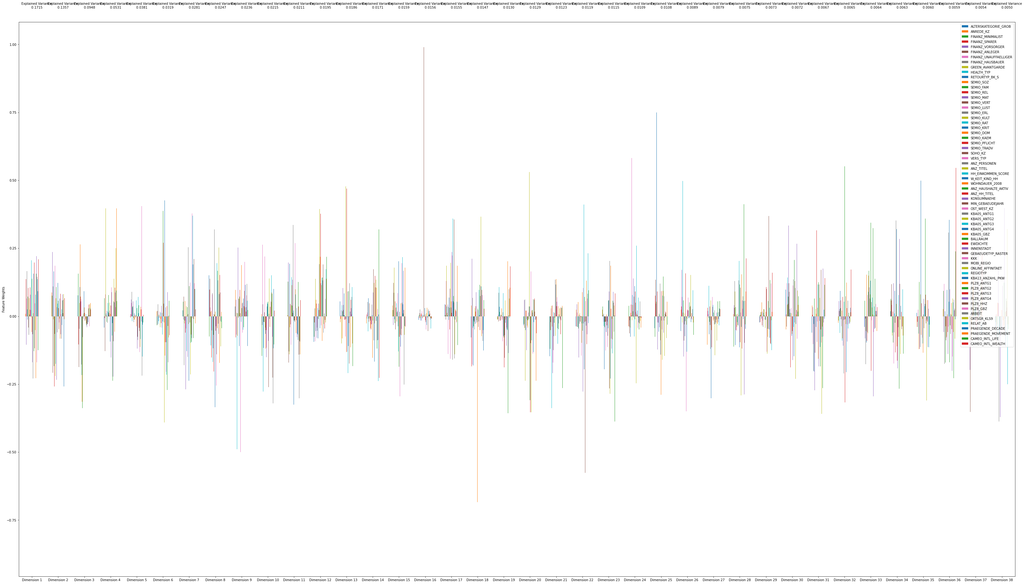

```python
pca_results(cleaned_data, pca)
```

### Discussion 2.3: Interpret Principal Components

- From the table above principle components(DimensionX) it's explained variance decrease as we introduce new Dimension
- In PCA, component loadings refers to the correlation between original variable and the component.
  - The positive values indicates a positive correlation
  - The negative values indicates an inverse correlation

## Step 3: Clustering

### Step 3.1: Apply Clustering to General Population

You've assessed and cleaned the demographics data, then scaled and transformed them. Now, it's time to see how the data clusters in the principal components space. In this substep, you will apply k-means clustering to the dataset and use the average within-cluster distances from each point to their assigned cluster's centroid to decide on a number of clusters to keep.

- Use sklearn's KMeans class to perform k-means clustering on the PCA-transformed data.
- Then, compute the average difference from each point to its assigned cluster's center. **Hint**: The KMeans object's `.score()` method might be useful here, but note that in sklearn, scores tend to be defined so that larger is better. Try applying it to a small, toy dataset, or use an internet search to help your understanding.
- Perform the above two steps for a number of different cluster counts. You can then see how the average distance decreases with an increasing number of clusters. However, each additional cluster provides a smaller net benefit. Use this fact to select a final number of clusters in which to group the data. **Warning**: because of the large size of the dataset, it can take a long time for the algorithm to resolve. The more clusters to fit, the longer the algorithm will take. You should test for cluster counts through at least 10 clusters to get the full picture, but you shouldn't need to test for a number of clusters above about 30.
- Once you've selected a final number of clusters to use, re-fit a KMeans instance to perform the clustering operation. Make sure that you also obtain the cluster assignments for the general demographics data, since you'll be using them in the final Step 3.3.

```python
# Over a number of different cluster counts...
def plt_kmean_score(data, min_clus:int, max_clus:int):
    scores = []
    for center in range(min_clus, max_clus):
        kmean = KMeans(n_clusters=center)
        model = kmean.fit(data)
        scores.append(abs(model.score(data)))
        print('Processing {}% ...'.format(int (center/(max_clus-min_clus)*100)))
    centers = list(range(min_clus, max_clus))
    plt.plot(centers, scores, marker='o')
    plt.xlabel('Centers')
    plt.ylabel('Average Distance')
    # run k-means clustering on the data and...
    # compute the average within-cluster distances.
```

```python
X_pca
```

```
array([[ 3.81620854e+00, -2.74440238e+00, -2.86945922e+00, ...,
         1.43166580e-01, -1.23615116e-01,  7.54800836e-01],
       [-9.33541519e-01,  2.13166054e-01, -3.09178751e+00, ...,
        -5.40621453e-01,  7.45829651e-01,  2.82679262e-01],
       [-3.88006591e+00,  1.45702375e+00, -6.98366115e-01, ...,
        -1.40085535e+00, -5.77281558e-01, -8.55000668e-01],
       ...,
       [-9.45792944e-01, -3.28120178e+00, -2.92241542e+00, ...,
        -2.62393166e-01,  6.11724050e-02, -7.20647054e-01],
       [ 5.80755007e+00, -3.48498553e+00,  2.32922697e+00, ...,
        -1.36115927e+00, -2.78638898e-01, -1.94085534e-03],
       [-6.18444393e-01,  1.14867860e+00,  3.09017620e+00, ...,
        -4.92922124e-01, -3.07979181e-01,  1.21265470e-01]])
```

```
Processing 7% ...
Processing 14% ...
Processing 21% ...
Processing 28% ...
Processing 35% ...
Processing 42% ...
Processing 50% ...
Processing 57% ...
Processing 64% ...
Processing 71% ...
Processing 78% ...
Processing 85% ...
Processing 92% ...
Processing 100% ...
```

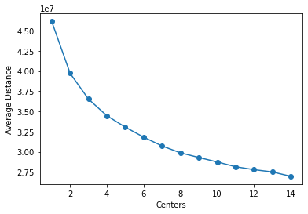

```python
# Investigate the change in within-cluster distance across number of clusters.
# HINT: Use matplotlib's plot function to visualize this relationship.
plt_kmean_score(X_pca, 1, 15)
```

```python
# Re-fit the k-means model with the selected number of clusters and obtain
# cluster predictions for the general population demographics data.
value_k = 4
kmean = KMeans(n_clusters=value_k)
general_kmean_model = kmean.fit(X_pca)
general_kmean_pred = kmean.predict(X_pca)
```

```python
# convert to DataFrame
general_kmean_pred = pd.DataFrame(general_kmean_pred)
```

### Discussion 3.1: Apply Clustering to General Population

From the plot above we can observe that the average distance decrease as we increase the clusters We need to divide our dataset to meaningful segment, and try to avoid too many segments as few segments can achieve what we need, so we decide to choose the number of clusters when the average distance dosen't change significantly from point to point Finally we decide to continue with 4 clusters

### Step 3.2: Apply All Steps to the Customer Data

Now that you have clusters and cluster centers for the general population, it's time to see how the customer data maps on to those clusters. Take care to not confuse this for re-fitting all of the models to the customer data. Instead, you're going to use the fits from the general population to clean, transform, and cluster the customer data. In the last step of the project, you will interpret how the general population fits apply to the customer data.

- Don't forget when loading in the customers data, that it is semicolon (`;`) delimited.
- Apply the same feature wrangling, selection, and engineering steps to the customer demographics using the `clean_data()` function you created earlier. (You can assume that the customer demographics data has similar meaning behind missing data patterns as the general demographics data.)
- Use the sklearn objects from the general demographics data, and apply their transformations to the customers data. That is, you should not be using a `.fit()` or `.fit_transform()` method to re-fit the old objects, nor should you be creating new sklearn objects! Carry the data through the feature scaling, PCA, and clustering steps, obtaining cluster assignments for all of the data in the customer demographics data.

```python
# Load in the customer demographics data.
customers = pd.read_csv('./Udacity_CUSTOMERS_Subset.csv', delimiter=';')
```

```python
# Apply preprocessing, feature transformation, and clustering from the general
# demographics onto the customer data, obtaining cluster predictions for the
# customer demographics data.
customers = clean_data(customers)
```

```
The time execution of (find_mis_vals_convert_to_nans) function is : 0.7687904834747314
```

```python
total_missing = customers.isna().sum().sum()
print ('Total number of missing data {}'.format(total_missing))
```

```
Total number of missing data 73879
```

```python
# Apply Iterative Imputer by using pre-initialized 'iterative_imp' object to fill missing values
clean_customers = pd.DataFrame (iterative_imp.transform(customers), columns=customers.columns)
```

```python
clean_customers
```

|  | ALTERSKATEGORIE_GROB | ANREDE_KZ | FINANZ_MINIMALIST | FINANZ_SPARER | FINANZ_VORSORGER | FINANZ_ANLEGER | FINANZ_UNAUFFAELLIGER | FINANZ_HAUSBAUER | GREEN_AVANTGARDE | HEALTH_TYP | ... | PLZ8_ANTG4 | PLZ8_HHZ | PLZ8_GBZ | ARBEIT | ORTSGR_KLS9 | RELAT_AB | PRAEGENDE_DECADE | PRAEGENDE_MOVEMENT | CAMEO_INTL_LIFE | CAMEO_INTL_WEALTH |
| --- | --- | --- | --- | --- | --- | --- | --- | --- | --- | --- | --- | --- | --- | --- | --- | --- | --- | --- | --- | --- | --- |
| 0 | 4.0 | 1.0 | 5.0 | 1.0 | 5.0 | 1.0 | 2.0 | 2.0 | 1.0 | 1.0 | ... | 0.000000 | 5.000000 | 5.000000 | 1.0 | 2.0 | 1.0 | 1.0 | 1.0 | 2.0 | 0.0 |
| 1 | 4.0 | 2.0 | 5.0 | 1.0 | 5.0 | 1.0 | 4.0 | 4.0 | 1.0 | 2.0 | ... | 1.000000 | 3.000000 | 2.000000 | 3.0 | 5.0 | 3.0 | 1.0 | 1.0 | 3.0 | 2.0 |
| 2 | 4.0 | 1.0 | 5.0 | 1.0 | 5.0 | 2.0 | 1.0 | 2.0 | 0.0 | 2.0 | ... | 0.000000 | 3.000000 | 4.000000 | 1.0 | 3.0 | 1.0 | 0.0 | 0.0 | 3.0 | 1.0 |
| 3 | 3.0 | 1.0 | 3.0 | 1.0 | 4.0 | 4.0 | 5.0 | 2.0 | 0.0 | 3.0 | ... | 1.000000 | 3.000000 | 3.000000 | 3.0 | 5.0 | 1.0 | 3.0 | 0.0 | 0.0 | 3.0 |
| 4 | 3.0 | 1.0 | 5.0 | 1.0 | 5.0 | 1.0 | 2.0 | 3.0 | 1.0 | 3.0 | ... | 1.000000 | 5.000000 | 5.000000 | 3.0 | 7.0 | 5.0 | 1.0 | 1.0 | 3.0 | 2.0 |
| ... | ... | ... | ... | ... | ... | ... | ... | ... | ... | ... | ... | ... | ... | ... | ... | ... | ... | ... | ... | ... | ... |
| 139498 | 3.0 | 1.0 | 5.0 | 1.0 | 5.0 | 1.0 | 1.0 | 2.0 | 1.0 | 3.0 | ... | 1.000000 | 5.000000 | 4.000000 | 3.0 | 8.0 | 5.0 | 1.0 | 1.0 | 3.0 | 0.0 |
| 139499 | 4.0 | 2.0 | 5.0 | 1.0 | 5.0 | 2.0 | 2.0 | 3.0 | 0.0 | 2.0 | ... | 0.336939 | 5.421708 | 5.541056 | 1.0 | 4.0 | 1.0 | 2.0 | 0.0 | 1.0 | 2.0 |
| 139500 | 4.0 | 1.0 | 5.0 | 1.0 | 5.0 | 1.0 | 1.0 | 2.0 | 1.0 | 2.0 | ... | 1.000000 | 5.000000 | 5.000000 | 3.0 | 7.0 | 5.0 | 1.0 | 1.0 | 3.0 | 1.0 |
| 139501 | 3.0 | 2.0 | 2.0 | 1.0 | 5.0 | 1.0 | 2.0 | 5.0 | 0.0 | 2.0 | ... | 1.000000 | 2.000000 | 3.000000 | 3.0 | 4.0 | 4.0 | 3.0 | 0.0 | 3.0 | 1.0 |
| 139502 | 2.0 | 1.0 | 5.0 | 1.0 | 5.0 | 1.0 | 1.0 | 2.0 | 0.0 | 2.0 | ... | 0.000000 | 4.000000 | 5.000000 | 1.0 | 3.0 | 1.0 | 1.0 | 0.0 | 2.0 | 2.0 |

139503 rows × 64 columns

```python
clean_customers.isna().sum().sum()
```

```
0
```

```python
# Apply Standard Scaler by using pre-initialized 'scaler' object
clean_customers = pd.DataFrame(scaler.transform(clean_customers), columns=clean_customers.columns)
```

```python
# use pca object with pre-defined num_features variable
cust_X_pca = pca.transform(clean_customers)
```

```python
cust_kmean_pred = general_kmean_model.predict(cust_X_pca)
```

```python
# convert to DataFrame
cust_kmean_pred = pd.DataFrame(cust_kmean_pred)
```

### Step 3.3: Compare Customer Data to Demographics Data

At this point, you have clustered data based on demographics of the general population of Germany, and seen how the customer data for a mail-order sales company maps onto those demographic clusters. In this final substep, you will compare the two cluster distributions to see where the strongest customer base for the company is.

Consider the proportion of persons in each cluster for the general population, and the proportions for the customers. If we think the company's customer base to be universal, then the cluster assignment proportions should be fairly similar between the two. If there are only particular segments of the population that are interested in the company's products, then we should see a mismatch from one to the other. If there is a higher proportion of persons in a cluster for the customer data compared to the general population (e.g. 5% of persons are assigned to a cluster for the general population, but 15% of the customer data is closest to that cluster's centroid) then that suggests the people in that cluster to be a target audience for the company. On the other hand, the proportion of the data in a cluster being larger in the general population than the customer data (e.g. only 2% of customers closest to a population centroid that captures 6% of the data) suggests that group of persons to be outside of the target demographics.

Take a look at the following points in this step:

- Compute the proportion of data points in each cluster for the general population and the customer data. Visualizations will be useful here: both for the individual dataset proportions, but also to visualize the ratios in cluster representation between groups. Seaborn's [`countplot()`](https://seaborn.pydata.org/generated/seaborn.countplot.html) or [`barplot()`](https://seaborn.pydata.org/generated/seaborn.barplot.html) function could be handy.
  - Recall the analysis you performed in step 1.1.3 of the project, where you separated out certain data points from the dataset if they had more than a specified threshold of missing values. If you found that this group was qualitatively different from the main bulk of the data, you should treat this as an additional data cluster in this analysis. Make sure that you account for the number of data points in this subset, for both the general population and customer datasets, when making your computations!
- Which cluster or clusters are overrepresented in the customer dataset compared to the general population? Select at least one such cluster and infer what kind of people might be represented by that cluster. Use the principal component interpretations from step 2.3 or look at additional components to help you make this inference. Alternatively, you can use the `.inverse_transform()` method of the PCA and StandardScaler objects to transform centroids back to the original data space and interpret the retrieved values directly.
- Perform a similar investigation for the underrepresented clusters. Which cluster or clusters are underrepresented in the customer dataset compared to the general population, and what kinds of people are typified by these clusters?

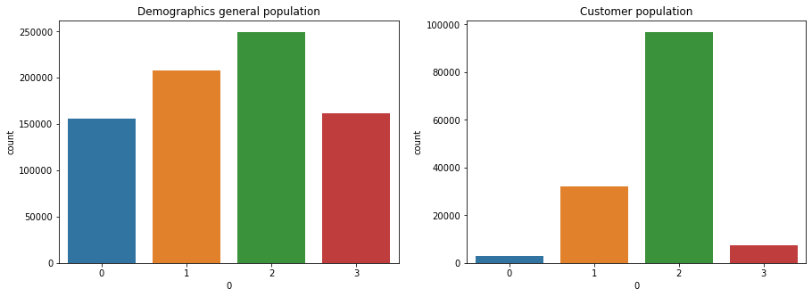

```python
# Compare the proportion of data in each cluster for the customer data to the
# proportion of data in each cluster for the general population.

fig, axs = plt.subplots(nrows=1, ncols=2, figsize=(15, 5))

ax = axs[0].set_title('Demographics general population')
sns.countplot( data=general_kmean_pred, x=0, ax=axs[0] )

ax = axs[1].set_title('Customer population')
sns.countplot( data=cust_kmean_pred, x=0, ax = axs[1] )
```

```python
# get percentage for each clusters
perc_clus_pop = pd.DataFrame()
general_pred_count = general_kmean_pred.value_counts()
cust_pred_count = cust_kmean_pred.value_counts()
for i in range(value_k):
    perc_clus_pop.loc[i, 'general population'] = general_pred_count[i]/len(general_kmean_pred)
    perc_clus_pop.loc[i, 'customer population'] = cust_pred_count[i]/len(cust_kmean_pred)
```

```python
print ('percentage of clusters of general, and customer populations')
perc_clus_pop
```

```
percentage of clusters of general, and customer populations
```

|  | general population | customer population |
| --- | --- | --- |
| 0 | 0.200638 | 0.021921 |
| 1 | 0.268515 | 0.231178 |
| 2 | 0.321908 | 0.694064 |
| 3 | 0.208939 | 0.052838 |

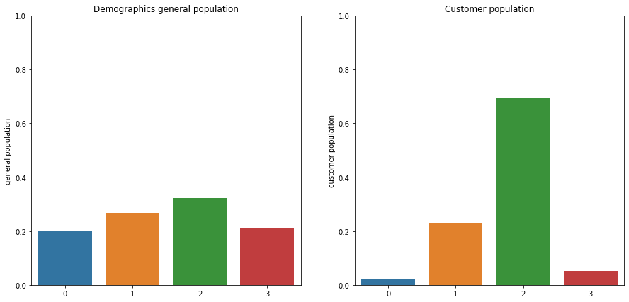

```python
fig, axs = plt.subplots(nrows=1, ncols=2, figsize=(15, 7))

ax = axs[0].set_title('Demographics general population')
axs[0].set_ylim(0, 1)
sns.barplot( data=perc_clus_pop,  x=perc_clus_pop.index, y='general population', ax=axs[0] )

ax = axs[1].set_title('Customer population')
axs[1].set_ylim(0, 1)
sns.barplot( data= perc_clus_pop, x=perc_clus_pop.index, y='customer population', ax = axs[1] )
```

```python
# What kinds of people are part of a cluster that is overrepresented in the
# customer data compared to the general population?
num_clus = 2
# Do the pca inverse with suitable reshape from (64,) to (1,64) using array.reshape(1, -1), because it contains Single sample then use scaler inverse.
scaler_inverse = scaler.inverse_transform (pca.inverse_transform(general_kmean_model.cluster_centers_[num_clus]).reshape(1, -1))
cnet_2_clus_data = pd.DataFrame (scaler_inverse, columns=clean_customers.columns)
```

```python
cnet_2_clus_data
```

|  | ALTERSKATEGORIE_GROB | ANREDE_KZ | FINANZ_MINIMALIST | FINANZ_SPARER | FINANZ_VORSORGER | FINANZ_ANLEGER | FINANZ_UNAUFFAELLIGER | FINANZ_HAUSBAUER | GREEN_AVANTGARDE | HEALTH_TYP | ... | PLZ8_ANTG4 | PLZ8_HHZ | PLZ8_GBZ | ARBEIT | ORTSGR_KLS9 | RELAT_AB | PRAEGENDE_DECADE | PRAEGENDE_MOVEMENT | CAMEO_INTL_LIFE | CAMEO_INTL_WEALTH |
| --- | --- | --- | --- | --- | --- | --- | --- | --- | --- | --- | --- | --- | --- | --- | --- | --- | --- | --- | --- | --- | --- |
| 0 | 3.420322 | 1.503493 | 4.329595 | 1.613248 | 4.271618 | 2.163424 | 1.925036 | 2.34851 | 0.401357 | 2.144566 | ... | 0.244422 | 3.463734 | 3.882004 | 2.778547 | 4.082394 | 2.560726 | 2.494606 | 0.401357 | 2.438266 | 1.284979 |

1 rows × 64 columns

```python
# What kinds of people are part of a cluster that is underrepresented in the
# customer data compared to the general population?
num_clus = 0
# Do the pca inverse with suitable reshape from (64,) to (1,64) using array.reshape(1, -1), because it contains Single sample then use scaler inverse.
scaler_inverse = scaler.inverse_transform (pca.inverse_transform(general_kmean_model.cluster_centers_[num_clus]).reshape(1, -1))
cnet_0_clus_data = pd.DataFrame (scaler_inverse, columns=clean_customers.columns)
```

```python
cnet_0_clus_data
```

|  | ALTERSKATEGORIE_GROB | ANREDE_KZ | FINANZ_MINIMALIST | FINANZ_SPARER | FINANZ_VORSORGER | FINANZ_ANLEGER | FINANZ_UNAUFFAELLIGER | FINANZ_HAUSBAUER | GREEN_AVANTGARDE | HEALTH_TYP | ... | PLZ8_ANTG4 | PLZ8_HHZ | PLZ8_GBZ | ARBEIT | ORTSGR_KLS9 | RELAT_AB | PRAEGENDE_DECADE | PRAEGENDE_MOVEMENT | CAMEO_INTL_LIFE | CAMEO_INTL_WEALTH |
| --- | --- | --- | --- | --- | --- | --- | --- | --- | --- | --- | --- | --- | --- | --- | --- | --- | --- | --- | --- | --- | --- |
| 0 | 1.800951 | 1.536608 | 1.527376 | 4.27902 | 2.179211 | 3.846001 | 3.708732 | 3.912806 | 0.07414 | 2.244198 | ... | 1.286364 | 3.761878 | 2.701471 | 3.671634 | 6.944175 | 3.731244 | 4.611232 | 0.07414 | 1.020614 | 3.374854 |

1 rows × 64 columns

#### ALTERSKATEGORIE_GROB

Estimated age based on given name analysis

- -1: unknown (missing)
- 0: unknown (cannot be determined)
- 1: < 30 years old
- 2: 30 - 45 years old
- 3: 46 - 60 years old
- 4: > 60 years old
- 9: uniformly distributed

#### ANREDE_KZ

Gender

- -1: unknown (missing)
- 0: unknown (cannot be determined)
- 1: male
- 2: female

#### FINANZ_MINIMALIST

Financial typology, for each dimension:

- -1: unknown
- 1: very high
- 2: high
- 3: average
- 4: low
- 5: very low

Reference:

Data_Dictioary.md

### Discussion 3.3: Compare Customer Data to Demographics Data

#### cluster #2 is overrepresented and promising to be the target audience of the company

let's take fast look at some features:

- ALTERSKATEGORIE_GROB(Estimated age based on given name analysis): 3.420322
  - The age promising to be within 46 - 60 years old
- ANREDE_KZ(Gender): 1.503493
  - The gender prmosing to be male or female
- FINANZ_MINIMALIST: 4.329595
  - The financial minimalist promising to be between very low and low

#### cluster #0 is underrepresented

let's take fast look at some features:

- ALTERSKATEGORIE_GROB(Estimated age based on given name analysis): 1.800951
  - The age promising to be younger than 45 years old
- ANREDE_KZ(Gender): 1.536608
  - The gender prmosing to be male or female
- FINANZ_MINIMALIST: 1.527376
  - The financial minimalist promising to be between high and very high

> Congratulations on making it this far in the project! Before you finish, make sure to check through the entire notebook from top to bottom to make sure that your analysis follows a logical flow and all of your findings are documented in **Discussion** cells. Once you've checked over all of your work, you should export the notebook as an HTML document to submit for evaluation. You can do this from the menu, navigating to **File -> Download as -> HTML (.html)**. You will submit both that document and this notebook for your project submission.

```python
!!jupyter nbconvert *.ipynb --to html
```